# How Age and Education Level Predict Who is More Likely to Receive a Flu Shot

PQHS 432 Project using a sample of 2000 subjects from the Ohio BRFSS 2024

Author

Lauren Sapienza

Published

2026-02-24

## R Packages and Setup

```r
knitr::opts_chunk$set(comment = NA)

library(janitor)
library(naniar)

library(broom)
library(car)
library(caret)
library(cutpointr)
library(GGally)
library(haven)
library(kableExtra)
library(mice)
library(patchwork)
library(pROC)
library(readxl)
library(rms)

library(easystats)
library(tidyverse)

theme_set(theme_bw())
```

# 1 Data Source

My data are sourced from the 2024 Behavioral Risk Factor Surveillance System (BRFSS) Survey, which are described and can be accessed [here](https://www.cdc.gov/brfss/annual_data/annual_2024.html).

The BRFSS survey is conducted by state health departments with assistance from the CDC, who aggregates and publishes the final data set each year. The aim is to gather data from adult US residents regarding their risk behaviors and health practices. Surveys are performed monthly over the phone and are divided into a land-line telephone sample and a cellular telephone sample.

# 2 The Subjects

Our population of interest includes over 6000 subjects with complete data on our logistic regression outcome: during the past 12 months, have you had either a flu vaccine that was sprayed in your nose or a flu shot injected into your arm? The population was created by filtering to subjects that responded that they lived in Ohio, are between 18 and 79 years old, and completed the interview. The population was then randomly sampled to create a final data set with only 2000 subjects.

# 3 Loading and Tidying the Data

## 3.1 Loading the Raw Data

```r
brfss_2024_raw <- read_xpt("LLCP2024.XPT")
```

## 3.2 Cleaning the Data

### 3.2.1 Selecting Variables We’ll Use

```r
brfss_2024_temp <- brfss_2024_raw |>
  filter(DISPCODE == 1100, `_STATE` == 39, CSTATE1 == 1 | STATERE1 == 1, `_AGE80` < 80) |>
  select(SEQNO, SEXVAR, PRIMINS2, MEDCOST1, ADDEPEV3, EDUCA, `_AGE80`,
         FLUSHOT7, `_URBSTAT`, `_BMI5`, MENTHLTH, GENHLTH) |>
  zap_label()
```

First we filter the data to subjects who finished the survey, answered they resided in Ohio, and are less than 80 years old. We filter the age like this because all ages above 79 are listed as 80. Then we select our variables of interest and get rid of any labels.

### 3.2.2 Changing Variable Names and Converting Variable Types

```r
brfss_2024_temp <- brfss_2024_temp |>
  replace_with_na_at(.vars = 'PRIMINS2', condition = ~ .x == 77) |>
  replace_with_na_at(.vars = 'PRIMINS2', condition = ~ .x == 99)

brfss_2024_temp <- brfss_2024_temp |>
  replace_with_na_at(.vars = 'MEDCOST1', condition = ~ .x == 7) |>
  replace_with_na_at(.vars = 'MEDCOST1', condition = ~ .x == 9)

brfss_2024_temp <- brfss_2024_temp |>
  replace_with_na_at(.vars = 'ADDEPEV3', condition = ~ .x == 7) |>
  replace_with_na_at(.vars = 'ADDEPEV3', condition = ~ .x == 9)

brfss_2024_temp <- brfss_2024_temp |>
  replace_with_na_at(.vars = 'EDUCA', condition = ~ .x == 9)

brfss_2024_temp <- brfss_2024_temp |>
  replace_with_na_at(.vars = 'FLUSHOT7', condition = ~ .x == 7) |>
  replace_with_na_at(.vars = 'FLUSHOT7', condition = ~ .x == 9)

brfss_2024_temp <- brfss_2024_temp |>
  replace_with_na_at(.vars = 'MENTHLTH', condition = ~ .x == 77) |>
  replace_with_na_at(.vars = 'MENTHLTH', condition = ~ .x == 99)

brfss_2024_temp <- brfss_2024_temp |>
  replace_with_na_at(.vars = 'GENTHLTH', condition = ~ .x == 77) |>
  replace_with_na_at(.vars = 'GENTHLTH', condition = ~ .x == 99)
```

Now we change survey answers coded as ‘Don’t Know’, ‘Refused’ or similar to missing values.

```r
brfss_2024_temp <- brfss_2024_temp |>
  mutate(sex = case_when(SEXVAR == 1 ~ "Male",
                         SEXVAR == 2 ~ "Female")) |>
  mutate(sex = factor(sex))

brfss_2024_temp <- brfss_2024_temp |>
  mutate(insur = case_when(PRIMINS2 == 1 | PRIMINS2 == 2 ~ "Private",
                           PRIMINS2 == 3 | PRIMINS2 == 4 ~ "Medicare",
                           PRIMINS2 == 5 ~ "Medicaid",
                           PRIMINS2 == 6 | PRIMINS2 == 7 | PRIMINS2 == 8 |
                           PRIMINS2 == 9 | PRIMINS2 == 10 | PRIMINS2 == 88 ~ "Other")) |>
  mutate(insur = factor(insur))

brfss_2024_temp <- brfss_2024_temp |>
  mutate(afford = case_when(MEDCOST1 == 1 ~ "Yes",
                            MEDCOST1 == 2 ~ "No")) |>
  mutate(afford = factor(afford))

brfss_2024_temp <- brfss_2024_temp |>
  mutate(depr = case_when(ADDEPEV3 == 1 ~ "Yes",
                          ADDEPEV3 == 2 ~ "No")) |>
  mutate(depr = factor(depr))

brfss_2024_temp <- brfss_2024_temp |>
  mutate(educ = case_when(EDUCA == 1 | EDUCA == 2 |
                          EDUCA == 3 | EDUCA == 4 ~ "HS_or_less",
                          EDUCA == 5 ~ "Some_College",
                          EDUCA == 6 ~ "College_Grad")) |>
  mutate(educ = factor(educ))

brfss_2024_temp <- brfss_2024_temp |>
  mutate(flushot = case_when(FLUSHOT7 == 1 ~ "Yes",
                             FLUSHOT7 == 2 ~ "No")) |>
  mutate(flushot = factor(flushot))

brfss_2024_temp <- brfss_2024_temp |>
  mutate(bmi = `_BMI5`/ 100)

brfss_2024_temp <- brfss_2024_temp |>
  mutate(age = `_AGE80`)

brfss_2024_temp <- brfss_2024_temp |>
  mutate(seqno = as.character(SEQNO))

brfss_2024_temp <- brfss_2024_temp |>
  mutate(rural = case_when(`_URBSTAT` == 1 ~ "Urban",
                           `_URBSTAT` == 2 ~ "Rural")) |>
  mutate(rural = factor(rural))

brfss_2024_temp <- brfss_2024_temp |>
  mutate(genhlth = case_when(GENHLTH == 1 ~ "Excellent",
                             GENHLTH == 2 ~ "Very_Good",
                             GENHLTH == 3 ~ "Good",
                             GENHLTH == 4 ~ "Fair",
                             GENHLTH == 5 ~ "Poor")) |>
  mutate(genhlth = factor(genhlth))

brfss_2024_temp <- brfss_2024_temp |>
  mutate(menthlth = if_else(MENTHLTH == 88, 0, MENTHLTH))
```

We also recode all the numeric values to their associated categories using the BRFSS 2024 code book. We also take this opportunity to rename the variables, collapse some categories, and make sure all the variables are the correct data type.

### 3.2.3 Working with Catergorial Predictors

```r
brfss_2024_temp <- brfss_2024_temp |>
  mutate(insur = fct_relevel(insur, "Private", "Medicare", "Medicaid", "Other"))

brfss_2024_temp <- brfss_2024_temp |>
  mutate(educ = fct_relevel(educ, "HS_or_less", "Some_College", "College_Grad"))

brfss_2024_temp <- brfss_2024_temp |>
  mutate(genhlth = fct_relevel(genhlth, "Excellent", "Very_Good", "Good", "Fair", "Poor"))
```

Here we relevel some of the factor variables so they are in a sensible order.

### 3.2.4 Arranging the Tibble

```r
brfss_2024_final <- brfss_2024_temp |>
  select(seqno, menthlth, flushot, age, sex, bmi,
         genhlth, depr, insur, afford, educ, rural) |>
  droplevels() |>
  janitor::clean_names()

brfss_2024_final <- brfss_2024_final |> filter(complete.cases(flushot))
```

We now select our new variables and put them in order so that our ID code (`seqno`) is first. We then drop any extra levels and filter to complete cases of our logistic regression outcome.

### 3.2.5 Sampling the Data

```r
set.seed(432)

brfss_2024 <- brfss_2024_final |> slice_sample(n=2000, replace=FALSE)
```

Last, we take a sample of our larger data set so that we only have 2000 subjects in our final tibble.

# 4 The Tidy Tibble

## 4.1 Listing the Tibble

```r
brfss_2024
```

```
# A tibble: 2,000 × 12
   seqno     menthlth flushot   age sex     bmi genhlth depr  insur afford educ
   <chr>        <dbl> <fct>   <dbl> <fct> <dbl> <fct>   <fct> <fct> <fct>  <fct>
 1 20240009…        0 Yes        72 Fema…  36.1 Good    No    Medi… No     Some…
 2 20240043…        0 No         78 Male   26.3 Fair    No    Other Yes    HS_o…
 3 20240046…       15 Yes        56 Male   30   Good    Yes   Other No     Coll…
 4 20240050…        0 Yes        69 Male   29.8 Good    No    Medi… No     Coll…
 5 20240096…        0 Yes        50 Fema…  NA   Excell… No    Priv… No     Some…
 6 20240060…        0 No         45 Male   30.5 Good    No    Priv… No     Some…
 7 20240057…        0 No         35 Fema…  37.1 Good    No    Priv… No     Some…
 8 20240077…       30 No         57 Male   15.9 Poor    Yes   Medi… No     Some…
 9 20240031…        4 Yes        26 Male   21.3 Excell… No    Priv… No     HS_o…
10 20240004…       10 Yes        65 Male   35.5 Fair    Yes   Medi… No     Coll…
# ℹ 1,990 more rows
# ℹ 1 more variable: rural <fct>
```

## 4.2 Size and Identifiers

Our analytic tibble, called `brfss_2024`, has 2000 rows (observations) on 12 columns (variables). Our indicator variable is `seqno`, and we have a unique `seqno` for each row in our data set, as the code below demonstrates.

```r
identical(nrow(brfss_2024), n_distinct(brfss_2024$seqno))
```

```
[1] TRUE
```

## 4.3 Saving as an Rds file

```r
write_rds(brfss_2024, "brfss_2024.Rds")
```

# 5 The Code Book

## 5.1 Five Key Statements

1. **Sample Size**: The data in our complete `brfss_2024` sample consist of 2000 subjects from the 2024 BRFSS between the ages of 18 and 79 in whom our logistic outcome variable (`flushot`) was measured.
2. **Missingness**: Of the 2000 subjects, 1781 have complete data on all variables listed below.
3. Our **outcome** variables are `menthlth`, which is the number of days in the last 30 the subject reported having poor mental health, for the linear regression, and `flushot`, which indicates whether or not the subject had a flu shot in the last 12 months, for the logistic regression. We are missing data for `menthlth`, as it will be filtered separately during the linear regression.
4. Candidate **predictors** for my models include `age`, `sex`, `bmi`, `genhlth`, and `depr` for the linear model and `age`, `insur`, `afford`, `educ`, and `rural` for the logistic model.
5. The only **other** variable contained in my tidy tibble is `seqno` which is the subject identifying code.

## 5.2 Describing the Variables

**Definitions**

| Variable | Role | Type | Description |
| --- | --- | --- | --- |
| `seqno` | identifier | - | BRFSS subject identifying code |
| `menthlth` | outcome (linear) | quant | For how many days during the past 30 days was your mental health not good? Number of days, 0-30 |
| `flushot` | outcome (logistic) | binary | During the past 12 months, have you had either a flu vaccine that was sprayed in your nose or a flu shot injected into your arm? (Yes/No) |
| `age` | predictor | quant | Imputed[^1] age in years, 18-79 |
| `sex` | predictor | binary | Sex of respondent, Male or Female |
| `bmi` | predictor | quant | Body Mass Index, kg/m<sup>2</sup> |
| `genhlth` | predictor | 5-cat | Would you say that in general your health is: Excellent, Very Good, Good, Fair, Poor? |
| `depr` | predictor | binary | Ever told you had a depressive disorder? (Yes/No) |
| `insur` | predictor | 4-cat | What is the current primary source of your health care coverage? Four categories: Private, Medicare, Medicaid, Other |
| `afford` | predictor | binary | Was there a time in the past 12 months when you needed to see a doctor but could not because you could not afford it? (Yes/No) |
| `educ` | predictor | 3-cat | What is the highest grade or year of school you completed? Three categories: High School or less, Some College, College Graduate |
| `rural` | predictor | binary | Urban/Rural status of county where subject lives, Urban or Rural |

**data_codebook()**

```r
data_codebook(brfss_2024 |> select(-seqno))
```

```
select(brfss_2024, -seqno) (2000 rows and 11 variables, 11 shown)

ID | Name     | Type        |   Missings |         Values |            N
---+----------+-------------+------------+----------------+-------------
1  | menthlth | numeric     |  25 (1.2%) |        [0, 30] |         1975
---+----------+-------------+------------+----------------+-------------
2  | flushot  | categorical |   0 (0.0%) |             No | 1098 (54.9%)
   |          |             |            |            Yes |  902 (45.1%)
---+----------+-------------+------------+----------------+-------------
3  | age      | numeric     |   0 (0.0%) |       [18, 79] |         2000
---+----------+-------------+------------+----------------+-------------
4  | sex      | categorical |   0 (0.0%) |         Female | 1066 (53.3%)
   |          |             |            |           Male |  934 (46.7%)
---+----------+-------------+------------+----------------+-------------
5  | bmi      | numeric     | 120 (6.0%) | [14.53, 73.18] |         1880
---+----------+-------------+------------+----------------+-------------
6  | genhlth  | categorical |   2 (0.1%) |      Excellent |  251 (12.6%)
   |          |             |            |      Very_Good |  661 (33.1%)
   |          |             |            |           Good |  678 (33.9%)
   |          |             |            |           Fair |  307 (15.4%)
   |          |             |            |           Poor |  101 ( 5.1%)
---+----------+-------------+------------+----------------+-------------
7  | depr     | categorical |  10 (0.5%) |             No | 1443 (72.5%)
   |          |             |            |            Yes |  547 (27.5%)
---+----------+-------------+------------+----------------+-------------
8  | insur    | categorical |  87 (4.3%) |        Private |  897 (46.9%)
   |          |             |            |       Medicare |  635 (33.2%)
   |          |             |            |       Medicaid |  162 ( 8.5%)
   |          |             |            |          Other |  219 (11.4%)
---+----------+-------------+------------+----------------+-------------
9  | afford   | categorical |   5 (0.2%) |             No | 1837 (92.1%)
   |          |             |            |            Yes |  158 ( 7.9%)
---+----------+-------------+------------+----------------+-------------
10 | educ     | categorical |   3 (0.1%) |     HS_or_less |  713 (35.7%)
   |          |             |            |   Some_College |  529 (26.5%)
   |          |             |            |   College_Grad |  755 (37.8%)
---+----------+-------------+------------+----------------+-------------
11 | rural    | categorical |   0 (0.0%) |          Rural |  156 ( 7.8%)
   |          |             |            |          Urban | 1844 (92.2%)
------------------------------------------------------------------------
```

**describe**

```r
describe(brfss_2024) |> html()
```

brfss_2024  
12 Variables 2000 Observations

seqno

| n | missing | distinct |
| --- | --- | --- |
| 2000 | 0 | 2000 |

| lowest : | 2024000333 | 2024000335 | 2024000340 | 2024000342 | 2024000363 |
| --- | --- | --- | --- | --- | --- |
| highest: | 2024010052 | 2024010056 | 2024010065 | 2024010067 | 2024010068 |

menthlth

| n | missing | distinct | Info | Mean | pMedian | Gmd | .05 | .10 | .25 | .50 | .75 | .90 | .95 |
| --- | --- | --- | --- | --- | --- | --- | --- | --- | --- | --- | --- | --- | --- |
| 1975 | 25 | 26 | 0.799 | 4.911 | 1.5 | 7.733 | 0 | 0 | 0 | 0 | 5 | 20 | 30 |

lowest : 0 1 2 3 4 , highest: 25 27 28 29 30

flushot

| n | missing | distinct |
| --- | --- | --- |
| 2000 | 0 | 2 |

```
 Value         No   Yes
 Frequency   1098   902
 Proportion 0.549 0.451
```

age

| n | missing | distinct | Info | Mean | pMedian | Gmd | .05 | .10 | .25 | .50 | .75 | .90 | .95 |
| --- | --- | --- | --- | --- | --- | --- | --- | --- | --- | --- | --- | --- | --- |
| 2000 | 0 | 62 | 1 | 55.54 | 56.5 | 18.26 | 24 | 31 | 44 | 59 | 69 | 74 | 77 |

lowest : 18 19 20 21 22 , highest: 75 76 77 78 79

sex

| n | missing | distinct |
| --- | --- | --- |
| 2000 | 0 | 2 |

```
 Value      Female   Male
 Frequency    1066    934
 Proportion  0.533  0.467
```

bmi

| n | missing | distinct | Info | Mean | pMedian | Gmd | .05 | .10 | .25 | .50 | .75 | .90 | .95 |
| --- | --- | --- | --- | --- | --- | --- | --- | --- | --- | --- | --- | --- | --- |
| 1880 | 120 | 768 | 1 | 29.44 | 28.8 | 7.485 | 20.37 | 21.95 | 24.41 | 28.25 | 32.98 | 38.28 | 42.51 |

lowest : 14.53 14.85 15.55 15.62 15.82 , highest: 58.56 62.47 66.56 67.93 73.18

genhlth

| n | missing | distinct |
| --- | --- | --- |
| 1998 | 2 | 5 |

```
 Value      Excellent Very_Good      Good      Fair      Poor
 Frequency        251       661       678       307       101
 Proportion     0.126     0.331     0.339     0.154     0.051
```

depr

| n | missing | distinct |
| --- | --- | --- |
| 1990 | 10 | 2 |

```
 Value         No   Yes
 Frequency   1443   547
 Proportion 0.725 0.275
```

insur

| n | missing | distinct |
| --- | --- | --- |
| 1913 | 87 | 4 |

```
 Value       Private Medicare Medicaid    Other
 Frequency       897      635      162      219
 Proportion    0.469    0.332    0.085    0.114
```

afford

| n | missing | distinct |
| --- | --- | --- |
| 1995 | 5 | 2 |

```
 Value         No   Yes
 Frequency   1837   158
 Proportion 0.921 0.079
```

educ

| n | missing | distinct |
| --- | --- | --- |
| 1997 | 3 | 3 |

```
 Value        HS_or_less Some_College College_Grad
 Frequency           713          529          755
 Proportion        0.357        0.265        0.378
```

rural

| n | missing | distinct |
| --- | --- | --- |
| 2000 | 0 | 2 |

```
 Value      Rural Urban
 Frequency    156  1844
 Proportion 0.078 0.922
```

**Missingness**

```r
miss_var_summary(brfss_2024) |> filter(n_miss > 0)
```

```
# A tibble: 7 × 3
  variable n_miss pct_miss
  <chr>     <int>    <num>
1 bmi         120     6
2 insur        87     4.35
3 menthlth     25     1.25
4 depr         10     0.5
5 afford        5     0.25
6 educ          3     0.15
7 genhlth       2     0.1
```

```r
miss_case_table(brfss_2024)
```

```
# A tibble: 4 × 3
  n_miss_in_case n_cases pct_cases
           <int>   <int>     <dbl>
1              0    1781     89.0
2              1     187      9.35
3              2      31      1.55
4              3       1      0.05
```

[^1]: Already imputed age was the only option for a continuous age variable in the BRFSS data set.

# 6 Linear Regression Design

## 6.1 My First Research Question

How well can you predict the number of poor mental health days someone has had using demographic factors such as sex and age, and health factors like self-reported overall health, BMI, and a previous depression diagnosis, in a sample of 679 subjects from the BRFSS 2024?

## 6.2 My Quantitative Outcome

```r
brfss_linear <- brfss_2024 |>
  filter(menthlth > 0 & menthlth < 30) |>
  filter(complete.cases(menthlth))
```

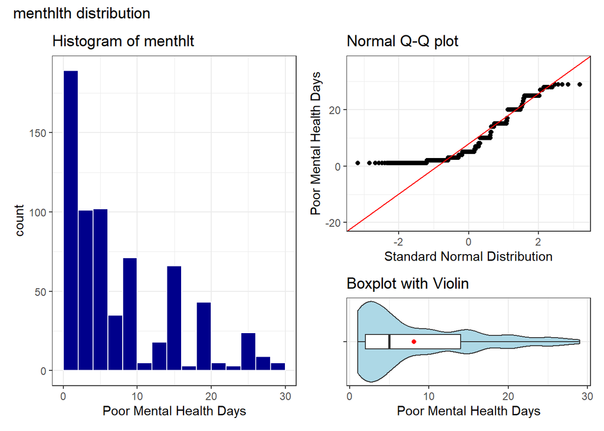

```r
p1 <- ggplot(brfss_linear, aes(x = menthlth)) +
  geom_histogram(bins = 15, col = "white", fill = "darkblue") +
  labs(title = "Histogram of menthlt", x = "Poor Mental Health Days")

p2 <- ggplot(brfss_linear, aes(sample = menthlth)) +
  geom_qq() +
  geom_qq_line(col = "red") +
  labs(y = "Poor Mental Health Days", x = "Standard Normal Distribution",
    title = "Normal Q-Q plot")

p3 <- ggplot(brfss_linear, aes(x = menthlth, y = "")) +
  geom_violin(fill = "lightblue", width = 1.1) +
  geom_boxplot(width = 0.2) +
  stat_summary(fun = mean, geom = "point", shape = 16, col = "red") +
  labs(y = "", x = "Poor Mental Health Days", title = "Boxplot with Violin")

p1 + (p2 / p3 + plot_layout(heights = c(2, 1))) +
  plot_annotation(title = "menthlth distribution")
```

### 6.2.1 Numerical Summary of my linear outcome

```r
Hmisc::describe(brfss_linear$menthlth)
```

```
brfss_linear$menthlth
       n  missing distinct     Info     Mean  pMedian      Gmd      .05
     679        0       24    0.988    8.099      7.5    7.732        1
     .10      .25      .50      .75      .90      .95
       1        2        5       14       20       25

lowest :  1  2  3  4  5, highest: 24 25 27 28 29
```

```r
mosaic::favstats(brfss_linear$menthlth)
```

```
 min Q1 median Q3 max     mean       sd   n missing
   1  2      5 14  29 8.098675 7.282783 679       0
```

```r
brfss_linear |> tabyl(menthlth) |> adorn_pct_formatting() |>
  arrange(desc(n)) |> head(5)
```

```
 menthlth   n percent
        2 111   16.3%
        5  94   13.8%
        1  78   11.5%
        3  74   10.9%
       10  71   10.5%
```

My outcome does not meet the rules given in the instructions as my outcome has values that exceed 10% of the data, as I thought my outcome was fine based on discussion in class and the check after Lab 4. I felt it was too late to change my outcome by the time I noticed this rule in the example project, so I apologize for this.

### 6.2.2 Summary Statements about my outcome, `menthlth`

My quantitative outcome is `menthlth` which represents the number of days in the last 30 that the subject had poor mental health. I am interested in exploring what variables have the strongest association with `menthlth` and how well we can predict `menthlth` from these variables.

- After filtering from the `brfss_2024` tibble to values of `menthlth` between 1 and 29, we have 679 subjects with complete data on the outcome.
- `menthlth` has 24 distinct values.
- The range is 1 to 29, with mean 8.099 days and standard deviation 7.282 days.
- The most common value for `menthlth` is 2, which occurs in 16.3% of my subjects.
- The distribution is skewed pretty heavily to the right, with a median of 5, as shown in the plots above. There also seems to be a bias for round numbers because of the nature of the survey question, which can be seen in the histogram spike around 15. Our distribution is heavy tailed, especially on the lower end of the range.

## 6.3 Linear Model Predictor Candidates

The predictors I intend to use in my linear model are `age` and `bmi`, which are quantitative, `sex` and `depr`, which are binary categorical variables, and `genhlth` which is a 5-category variable in my `brfss_linear` tibble.

- `age` has 62 distinct values, and is measured in years.
- `bmi` has 402 distinct values, and is measured in kg/m<sup>2</sup>. `bmi` has 37 missing values.
- `sex` has two levels, with 415 female and 264 male subjects.
- `depr` also has two levels, with 295 subjects answering “Yes” and 377 answering “No”. `depr` has 7 missing values.
- `genhlth`’s five categories have at least 30 observations in each level, as we can see in the table below.

```r
brfss_linear |> select(genhlth) |> summary()
```

```
      genhlth
 Excellent: 65
 Very_Good:210
 Good     :233
 Fair     :138
 Poor     : 33
```

### 6.3.1 Anticipated Direction of Effects

I believe that a larger amount of poor mental health days will be associated with lower age, higher bmi, with females, with ‘yes’ for a depression diagnosis, and with lower self reported overall health.

### 6.3.2 Missingness Summary

```r
linear_model_predictors <- brfss_linear |> select(age, sex, bmi, genhlth, depr)

miss_var_summary(linear_model_predictors) |> filter(n_miss > 0)
```

```
# A tibble: 2 × 3
  variable n_miss pct_miss
  <chr>     <int>    <num>
1 bmi          37     5.45
2 depr          7     1.03
```

```r
miss_case_table(linear_model_predictors)
```

```
# A tibble: 2 × 3
  n_miss_in_case n_cases pct_cases
           <int>   <int>     <dbl>
1              0     635     93.5
2              1      44      6.48
```

- I have complete data for all of the linear model predictors in 635 (93.5%) of the 679 rows in my data.
- I am missing 37 values (5.45%) for `bmi`.
- I am missing 7 values (1.03%) for `depr`.

# 7 Logistic Regression Design

## 7.1 My Second Research Question

What variables have the largest effect size when predicting whether or not a person has had a flu shot, from the variables of age, education level, living in a rural or urban county, insurance type, and whether the person can afford to see a doctor, in a sample of 2000 subjects from the 2024 BRFSS?

## 7.2 My Binary Outcome

```r
brfss_2024 <- brfss_2024 |>
  mutate(flushot = case_when(flushot == 'Yes' ~ 1,
                             flushot == 'No' ~ 0))
```

Here we recode `flushot` so that answers of ‘Yes’ are 1 and answers of ‘No’ are 0.

```r
brfss_2024 |> tabyl(flushot) |> adorn_pct_formatting()
```

```
 flushot    n percent
       0 1098   54.9%
       1  902   45.1%
```

## 7.3 Logistic Model Predictor Candidates

The predictors I intend to use in my logistic model are `age` which is quantitative and was previously described, `insur` and `educ`, which are categorical variables with 4 and 3 levels respectively, and `rural` and `afford` which are binary category variables.

- `insur` has 4 levels with at least 30 observations in each level, as we can see in the table below. `insur` has 87 missing values.
- `educ` has 3 levels with at least 30 observations in each level, as we can see in the table below. `educ` has 3 missing values.
- `rural` has two levels, with 156 subjects living in rural counties and 1844 subjects living in urban counties.
- `afford` has two levels with 158 subjects answering ‘Yes’ and 1837 subjects answering ‘No’. `afford` has 5 missing values.

```r
brfss_2024 |> tabyl(insur, flushot)
```

```
    insur   0   1
  Private 511 386
 Medicare 279 356
 Medicaid 109  53
    Other 143  76
     <NA>  56  31
```

```r
brfss_2024 |> tabyl(educ, flushot)
```

```
         educ   0   1
   HS_or_less 461 252
 Some_College 312 217
 College_Grad 324 431
         <NA>   1   2
```

### 7.3.1 Anticipated Direction of Effects

I believe that higher rates of having a flu shot will be associated with higher age, Medicare for insurance, higher education levels, subjects living in urban counties, and with being able to always afford to go to the doctor.

### 7.3.2 Missingness Summary

```r
logistic_model_predictors <- brfss_2024 |> select(age, insur, educ, rural, afford)

miss_var_summary(logistic_model_predictors) |> filter(n_miss > 0)
```

```
# A tibble: 3 × 3
  variable n_miss pct_miss
  <chr>     <int>    <num>
1 insur        87     4.35
2 afford        5     0.25
3 educ          3     0.15
```

```r
miss_case_table(logistic_model_predictors)
```

```
# A tibble: 3 × 3
  n_miss_in_case n_cases pct_cases
           <int>   <int>     <dbl>
1              0    1906     95.3
2              1      93      4.65
3              2       1      0.05
```

- I have complete data for all of the logistic model predictors in 1906 (95.3%) of the 2000 rows in my data.
- I am missing 87 values (4.35%) for `insur`.
- I am missing 5 values (0.25%) for `afford`.
- I am missing 3 values (0.15%) for `educ`.

# 8 Linear Regression Analyses

## 8.1 Missingness

I will be assuming my predictor variables are missing at random and so I will be using single imputation for my analysis. I am also assuming my outcome, `menthlth`, is missing completely at random, so we filtered to complete cases earlier.

```r
miss_var_summary(linear_model_predictors) |> filter(n_miss > 0)
```

```
# A tibble: 2 × 3
  variable n_miss pct_miss
  <chr>     <int>    <num>
1 bmi          37     5.45
2 depr          7     1.03
```

I am missing data on two of my predictors before imputation, `bmi` and `depr`.

```r
brfss_lin_imp <-
  mice(brfss_linear, m = 1, seed = 432, print = FALSE) |>
  complete() |>
  tibble()
```

```r
n_miss(brfss_lin_imp)
```

```
[1] 0
```

After imputation, we quickly check that we have no missing data, which is true.

## 8.2 Outcome Transformation

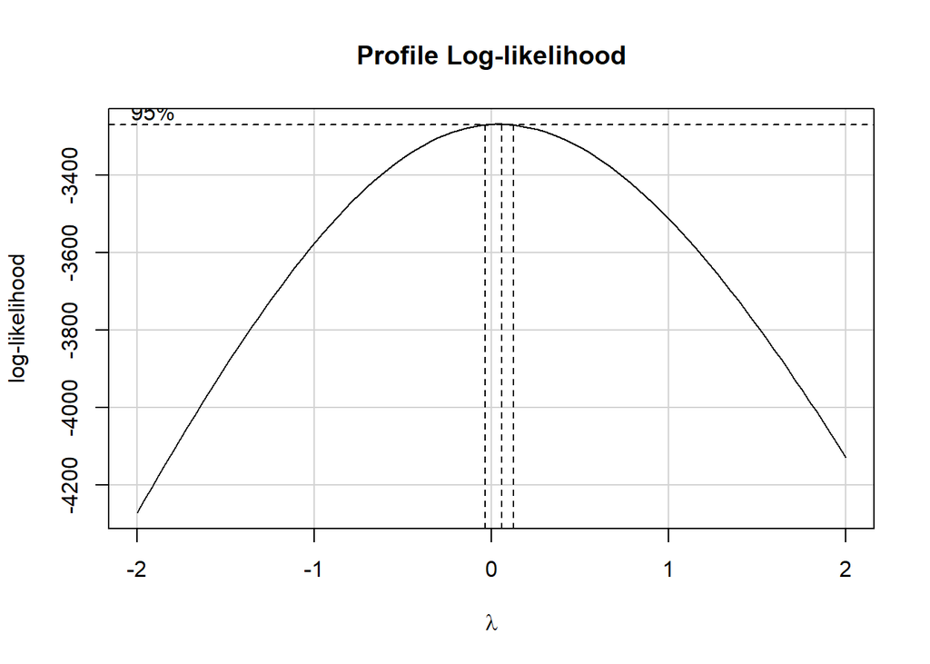

```r
mod_temp <- lm(menthlth ~ age + sex + bmi + genhlth + depr,
               data = brfss_lin_imp)

boxCox(mod_temp)
```

The Box-Cox plot suggests using a logarithm transformation, so we will check the plots of the distribution and compare to the untransformed plots from Section 6.2.

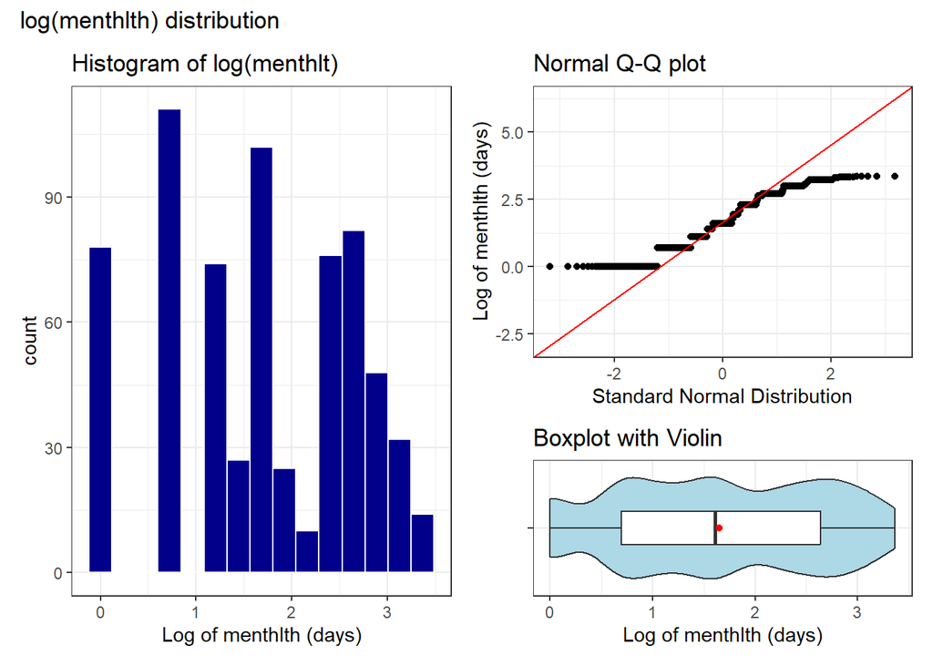

```r
brfss_lin_imp <- brfss_lin_imp |>
  mutate(log_ment = log(menthlth))

p1 <- ggplot(brfss_lin_imp, aes(x = log_ment)) +
  geom_histogram(bins = 15, col = "white", fill = "darkblue") +
  labs(title = "Histogram of log(menthlt)", x = "Log of menthlth (days)")

p2 <- ggplot(brfss_lin_imp, aes(sample = log_ment)) +
  geom_qq() +
  geom_qq_line(col = "red") +
  labs(y = "Log of menthlth (days)", x = "Standard Normal Distribution",
    title = "Normal Q-Q plot")

p3 <- ggplot(brfss_lin_imp, aes(x = log_ment, y = "")) +
  geom_violin(fill = "lightblue") +
  geom_boxplot(width = 0.3) +
  stat_summary(fun = mean, geom = "point", shape = 16, col = "red") +
  labs(y = "", x = "Log of menthlth (days)", title = "Boxplot with Violin")

p1 + (p2 / p3 + plot_layout(heights = c(2, 1))) +
  plot_annotation(title = "log(menthlth) distribution")
```

Our distribution appears to be more normally distributed after the transformation, especially looking at the box plot, so we will continue with using the transformed outcome. However, our histogram and normal Q-Q plot still show some issues with normality.

## 8.3 Scatterplot Matrix and Collinearity

Now we can look at the scatter plot matrix after transformation and imputation.

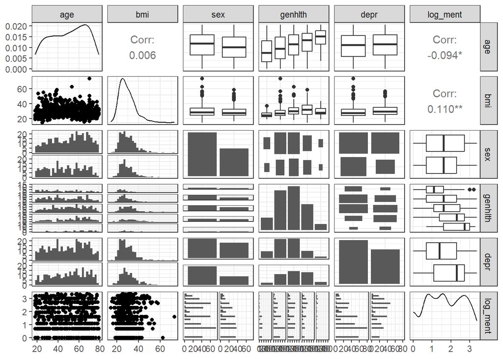

```r
ggpairs(brfss_lin_imp, columns = c("age", "bmi", "sex",
                               "genhlth", "depr", "log_ment"))
```

It does not look like we will have any issues with collinearity, but we quickly check the generalized VIF to make sure.

```r
modelA <- lm(log_ment ~ age + bmi + sex + genhlth + depr,
             data = brfss_lin_imp)

car::vif(modelA)
```

```
            GVIF Df GVIF^(1/(2*Df))
age     1.081864  1        1.040127
bmi     1.100415  1        1.049006
sex     1.052734  1        1.026028
genhlth 1.248851  4        1.028167
depr    1.095112  1        1.046476
```

None of our generalized VIF values are large enough to be of concern, so we are good to continue.

## 8.4 Model A

### 8.4.1 Fitting Model A

```r
modelA_lm <- lm(log_ment ~ age + bmi + sex + genhlth + depr,
                data = brfss_lin_imp)

dd <- datadist(brfss_lin_imp)
options(datadist = "dd")

modelA_ols <- ols(log_ment ~ age + bmi + sex + genhlth + depr,
                  data = brfss_lin_imp, x = TRUE, y = TRUE)
```

We fit using both lm and ols so we can use them with different functions later on. For model A we are using all predictor variables: `age`, `bmi`, `sex`, `genhlth`, and `depr`.

### 8.4.2 Tidied Coefficient Estimates (Model A)

```r
model_parameters(modelA_lm, ci = 0.90) |> print_md(digits = 3)
```

| Parameter | Coefficient | SE | 90% CI | t(670) | p |
| --- | --- | --- | --- | --- | --- |
| (Intercept) | 1.508 | 0.203 | (1.174, 1.843) | 7.423 | < .001 |
| age | -0.010 | 0.002 | (-0.014, -0.007) | -4.675 | < .001 |
| bmi | 0.003 | 0.005 | (-0.005, 0.011) | 0.577 | 0.564 |
| sex (Male) | -0.154 | 0.074 | (-0.276, -0.032) | -2.082 | 0.038 |
| genhlth (Very_Good) | 0.245 | 0.132 | (0.028, 0.462) | 1.862 | 0.063 |
| genhlth (Good) | 0.464 | 0.134 | (0.244, 0.684) | 3.470 | < .001 |
| genhlth (Fair) | 0.750 | 0.148 | (0.505, 0.994) | 5.051 | < .001 |
| genhlth (Poor) | 1.080 | 0.203 | (0.745, 1.415) | 5.312 | < .001 |
| depr (Yes) | 0.405 | 0.074 | (0.282, 0.527) | 5.450 | < .001 |

Looking at the variable of `age`, if we have two subjects with the same values of `bmi`, `sex`, `genhlth`, and `depr`, but subject A has a value of `age` that is 1 year larger than subject B, our model A predicts that subject A’s outcome `log(menthlth)` will be 0.01 less than subject B. In addition, our data are consistent at the 90% confidence level with a difference in our outcome `log(menthlth)` falling between -0.014 and -0.007, assuming both that our data are a random sample of the population of interest, and that our model A is correct.

### 8.4.3 Summarizing Fit (Model A)

```r
model_performance(modelA_lm) |> print_md(digits = 3)
```

Indices of model performance

| AIC | AICc | BIC | R2 | R2 (adj.) | RMSE | Sigma |
| --- | --- | --- | --- | --- | --- | --- |
| 1821.2 | 1821.6 | 1866.4 | 0.153 | 0.143 | 0.912 | 0.918 |

```r
glance(modelA_lm) |>
  select(r2 = r.squared, adjr2 = adj.r.squared, sigma,
         AIC, BIC, nobs, df, df.residual) |>
  kable(digits = c(3, 3, 3, 1, 1, 0, 0, 0))
```

| r2 | adjr2 | sigma | AIC | BIC | nobs | df | df.residual |
| --- | --- | --- | --- | --- | --- | --- | --- |
| 0.153 | 0.143 | 0.918 | 1821.2 | 1866.4 | 679 | 8 | 670 |

Our adjusted R<sup>2</sup> is pretty close to zero, which implies that our variables are not accounting for much of the variation of our data. We can also see that we are using 8 degrees of freedom in model A.

### 8.4.4 Regression Diagnostics (Model A)

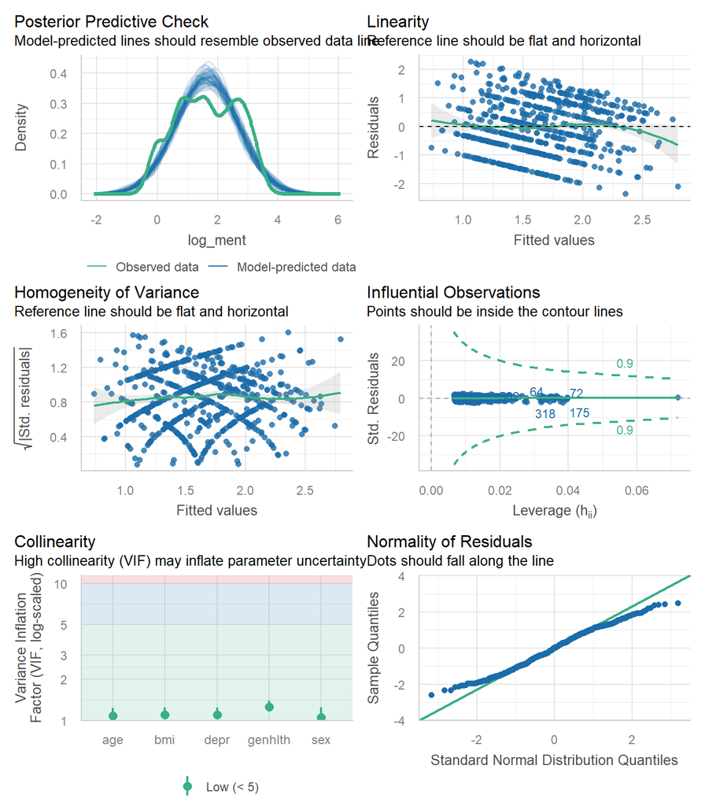

```r
check_model(modelA_lm, detrend = FALSE)
```

Our assumptions of linearity and homogeneity seem to hold up well, with perhaps some minor issues at both ends. We do not have any influential observations or issues with collinearity. Our normality plot also looks okay, but it looks like there may be some issues with normality at the ends. Our posterior predictive check does not look good at all, with most of the data not lining up well with the predicted data.

## 8.5 Non-Linearity

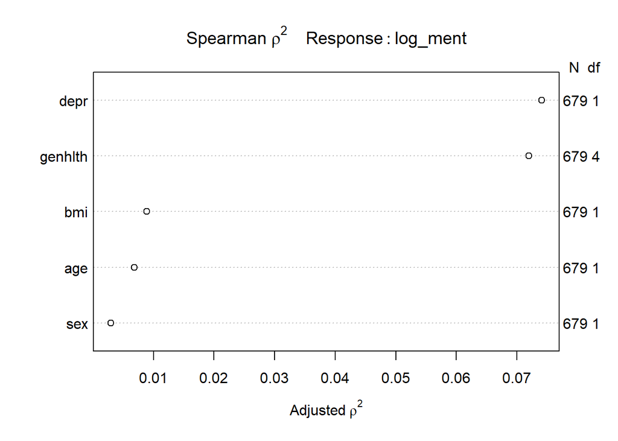

```r
plot(spearman2(log_ment ~ age + bmi + sex + genhlth + depr,
                data = brfss_lin_imp))
```

It looks like `depr` and `genhlth` will have the greatest impact on the model as nonlinear terms, so we will create an interaction between them that adds an additional 4 degrees of freedom. `bmi` doesn’t has as big of an impact according to our plot, but as it is the next best I will add a 4-degree restricted cubic spline, which has 3 degrees of freedom.

## 8.6 Model B

Model B will contain two non-linear terms, adding up to an additional 6 degrees of freedom, to model A. Model B will also continue to use all 5 of our selected predictors.

### 8.6.1 Fitting Model B

```r
modelB_lm <- lm(log_ment ~ age + rcs(bmi, 4) + sex + genhlth * depr,
                data = brfss_lin_imp)

dd <- datadist(brfss_lin_imp)
options(datadist = "dd")

modelB_ols <- ols(log_ment ~ age + rcs(bmi, 4) + sex + genhlth * depr,
                data = brfss_lin_imp, x = TRUE, y = TRUE)
```

Once again, we fit with both lm and ols.

### 8.6.2 Tidied Coefficient Estimates (Model B)

```r
model_parameters(modelB_lm, ci = 0.90) |> print_md(digits = 3)
```

| Parameter | Coefficient | SE | 90% CI | t(664) | p |
| --- | --- | --- | --- | --- | --- |
| (Intercept) | 1.721 | 0.620 | (0.700, 2.743) | 2.776 | 0.006 |
| age | -0.010 | 0.002 | (-0.014, -0.006) | -4.557 | < .001 |
| rcs(bmi ( degree) | -0.010 | 0.027 | (-0.054, 0.035) | -0.355 | 0.722 |
| rcs(bmi ( degree) | 0.067 | 0.133 | (-0.152, 0.286) | 0.502 | 0.616 |
| rcs(bmi ( degree) | -0.157 | 0.316 | (-0.677, 0.364) | -0.496 | 0.620 |
| sex (Male) | -0.144 | 0.075 | (-0.267, -0.020) | -1.917 | 0.056 |
| genhlth (Very_Good) | 0.329 | 0.154 | (0.075, 0.583) | 2.131 | 0.033 |
| genhlth (Good) | 0.500 | 0.158 | (0.240, 0.760) | 3.169 | 0.002 |
| genhlth (Fair) | 0.777 | 0.192 | (0.460, 1.094) | 4.039 | < .001 |
| genhlth (Poor) | 1.460 | 0.300 | (0.966, 1.954) | 4.866 | < .001 |
| depr (Yes) | 0.657 | 0.266 | (0.218, 1.095) | 2.468 | 0.014 |
| genhlth (Very_Good) × depr (Yes) | -0.312 | 0.297 | (-0.801, 0.177) | -1.050 | 0.294 |
| genhlth (Good) × depr (Yes) | -0.203 | 0.292 | (-0.685, 0.278) | -0.696 | 0.487 |
| genhlth (Fair) × depr (Yes) | -0.216 | 0.312 | (-0.729, 0.298) | -0.691 | 0.490 |
| genhlth (Poor) × depr (Yes) | -0.752 | 0.426 | (-1.454, -0.051) | -1.767 | 0.078 |

Looking at the variable of `sex`, if we have two subjects with the same values of `bmi`, `age`, `genhlth`, and `depr`, but subject A has a `sex` of male and subject B has a `sex` of female, our model B predicts that subject A’s outcome `log(menthlth)` will be 0.144 less subject B. In addition, our data are consistent at the 90% confidence level with a difference in our outcome `log(menthlth)` falling between -0.267 and -0.020, assuming both that our data are a random sample of the population of interest, and that our model B is correct.

### 8.6.3 Effects Plot for Model B

```r
summary(modelB_ols, conf.int = 0.90) |> kable(digits = 3)
```

|  | Low | High | Diff. | Effect | S.E. | Lower 0.9 | Upper 0.9 | Type |
| --- | --- | --- | --- | --- | --- | --- | --- | --- |
| age | 36.000 | 65.000 | 29.00 | -0.291 | 0.064 | -0.396 | -0.186 | 1 |
| bmi | 24.305 | 33.285 | 8.98 | 0.057 | 0.090 | -0.092 | 0.206 | 1 |
| sex - Male:Female | 1.000 | 2.000 | NA | -0.144 | 0.075 | -0.267 | -0.020 | 1 |
| genhlth - Excellent:Good | 3.000 | 1.000 | NA | -0.500 | 0.158 | -0.760 | -0.240 | 1 |
| genhlth - Very_Good:Good | 3.000 | 2.000 | NA | -0.171 | 0.115 | -0.360 | 0.019 | 1 |
| genhlth - Fair:Good | 3.000 | 4.000 | NA | 0.277 | 0.154 | 0.023 | 0.531 | 1 |
| genhlth - Poor:Good | 3.000 | 5.000 | NA | 0.960 | 0.278 | 0.501 | 1.418 | 1 |
| depr - Yes:No | 1.000 | 2.000 | NA | 0.453 | 0.123 | 0.251 | 0.655 | 1 |

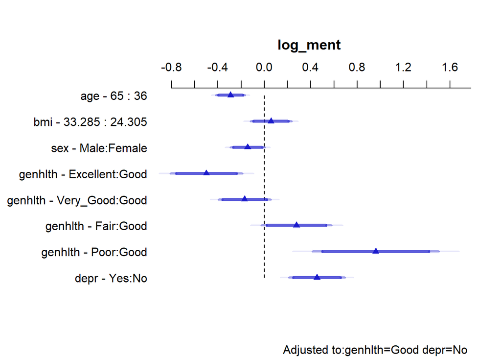

```r
plot(summary(modelB_ols, conf.int = 0.90))
```

It looks like the best and worst levels of `genhlth` have pretty large effect sizes when corrected for `depr` = No. `depr` is also has a pretty large effect size when corrected for `genhlth` = Good.

### 8.6.4 Summarizing Fit (Model B)

```r
model_performance(modelB_lm) |> print_md(digits = 3)
```

Indices of model performance

| AIC | AICc | BIC | R2 | R2 (adj.) | RMSE | Sigma |
| --- | --- | --- | --- | --- | --- | --- |
| 1829.4 | 1830.2 | 1901.7 | 0.157 | 0.140 | 0.909 | 0.919 |

```r
glance(modelB_lm) |>
  select(r2 = r.squared, adjr2 = adj.r.squared, sigma,
         AIC, BIC, nobs, df, df.residual) |>
  kable(digits = c(3, 3, 3, 1, 1, 0, 0, 0))
```

| r2 | adjr2 | sigma | AIC | BIC | nobs | df | df.residual |
| --- | --- | --- | --- | --- | --- | --- | --- |
| 0.157 | 0.14 | 0.919 | 1829.4 | 1901.7 | 679 | 14 | 664 |

Our performance for model B doesn’t appear to be too different from model A, however model B has a higher AIC, BIC, and a lower adjusted R<sup>2</sup> than model A. We also see that model B uses 14 degrees of freedom, 6 more than model A like we wanted.

### 8.6.5 Regression Diagnostics (Model B)

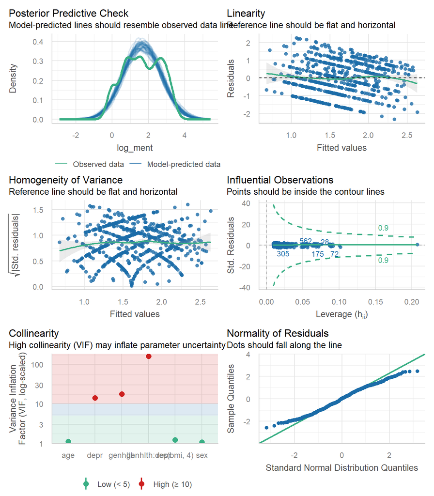

```r
check_model(modelB_lm, detrend = FALSE)
```

Everything here looks similar to model A with no problems with assumptions of linearity or homogeneity of variance and no influential observations. It still looks like there may be some issues with normality and the posterior predictive check is just as bad as model A. The collinearity was introduced by our interaction term, so there are no concerns there.

## 8.7 Validating Models A and B

```r
set.seed(4321); (valA <- validate(modelA_ols, method = "boot", B = 300))
```

```
          index.orig training   test optimism index.corrected   Lower  Upper
R-square      0.1527   0.1597 0.1415   0.0182          0.1345  0.0771 0.1888
MSE           0.8310   0.8203 0.8419  -0.0217          0.8527  0.7787 0.9246
g             0.4411   0.4472 0.4275   0.0197          0.4214  0.3441 0.5069
Intercept     0.0000   0.0000 0.0578  -0.0578          0.0578 -0.3833 0.3794
Slope         1.0000   1.0000 0.9638   0.0362          0.9638  0.7737 1.2256
            n
R-square  300
MSE       300
g         300
Intercept 300
Slope     300
```

```r
set.seed(4322); (valB <- validate(modelB_ols, method = "boot", B = 300))
```

```
          index.orig training   test optimism index.corrected   Lower  Upper
R-square      0.1575   0.1755 0.1387   0.0368          0.1207  0.0610 0.1724
MSE           0.8263   0.8067 0.8447  -0.0380          0.8643  0.7923 0.9284
g             0.4495   0.4706 0.4256   0.0450          0.4045  0.3311 0.4738
Intercept     0.0000   0.0000 0.1551  -0.1551          0.1551 -0.1728 0.4277
Slope         1.0000   1.0000 0.9062   0.0938          0.9062  0.7473 1.0976
            n
R-square  300
MSE       300
g         300
Intercept 300
Slope     300
```

### 8.7.1 Validated $R^2$ and other statistics

| Model | Validated $R^2$ | Validated MSE | AIC | BIC | df |
| --- | --- | --- | --- | --- | --- |
| A | 0.1345 | 0.8527 | 1821.2 | 1866.4 | 8 |
| B | 0.1207 | 0.8643 | 1829.4 | 1901.7 | 14 |

## 8.8 Final Linear Regression Model

I prefer model A because it does better than model B in validated R<sup>2</sup>, validated MSE, AIC, and BIC. Overall, model A beats model B in most statistics while being simpler than the augmented model B. They also performed very similarly in the `check_model` plots, so it seems that model A is the better pick.

### 8.8.1 Winning Model’s Parameter Estimates

```r
modelA_ols
```

```
Linear Regression Model

ols(formula = log_ment ~ age + bmi + sex + genhlth + depr, data = brfss_lin_imp,
    x = TRUE, y = TRUE)

                Model Likelihood    Discrimination
                      Ratio Test           Indexes
Obs     679    LR chi2    112.48    R2       0.153
sigma0.9177    d.f.            8    R2 adj   0.143
d.f.    670    Pr(> chi2) 0.0000    g        0.441

Residuals

     Min       1Q   Median       3Q      Max
-2.35540 -0.69246  0.03234  0.72572  2.27232

                  Coef    S.E.   t     Pr(>|t|)
Intercept          1.5083 0.2032  7.42 <0.0001
age               -0.0101 0.0022 -4.68 <0.0001
bmi                0.0029 0.0050  0.58 0.5644
sex=Male          -0.1543 0.0741 -2.08 0.0378
genhlth=Very_Good  0.2453 0.1317  1.86 0.0630
genhlth=Good       0.4639 0.1337  3.47 0.0006
genhlth=Fair       0.7495 0.1484  5.05 <0.0001
genhlth=Poor       1.0803 0.2034  5.31 <0.0001
depr=Yes           0.4046 0.0742  5.45 <0.0001
```

In addition to the R<sup>2</sup> and adjusted R<sup>2</sup> values presented above, our validated R<sup>2</sup>, as calculated in the previous section, is 0.1345.

```r
model_parameters(modelA_lm, ci = 0.90) |> print_md(digits = 3)
```

| Parameter | Coefficient | SE | 90% CI | t(670) | p |
| --- | --- | --- | --- | --- | --- |
| (Intercept) | 1.508 | 0.203 | (1.174, 1.843) | 7.423 | < .001 |
| age | -0.010 | 0.002 | (-0.014, -0.007) | -4.675 | < .001 |
| bmi | 0.003 | 0.005 | (-0.005, 0.011) | 0.577 | 0.564 |
| sex (Male) | -0.154 | 0.074 | (-0.276, -0.032) | -2.082 | 0.038 |
| genhlth (Very_Good) | 0.245 | 0.132 | (0.028, 0.462) | 1.862 | 0.063 |
| genhlth (Good) | 0.464 | 0.134 | (0.244, 0.684) | 3.470 | < .001 |
| genhlth (Fair) | 0.750 | 0.148 | (0.505, 0.994) | 5.051 | < .001 |
| genhlth (Poor) | 1.080 | 0.203 | (0.745, 1.415) | 5.312 | < .001 |
| depr (Yes) | 0.405 | 0.074 | (0.282, 0.527) | 5.450 | < .001 |

It looks like in our final model that `age`, and a `sex` of male are negatively related to our outcome `log(menthlth)`. `bmi`, a `depr` value of ‘Yes’, and `genhlth` values of ‘Very Good’, ‘Good’, ‘Fair’, and ‘Poor’ are positively related to the outcome `log(menthlth)`.

### 8.8.2 Effects Plot for Winning Model

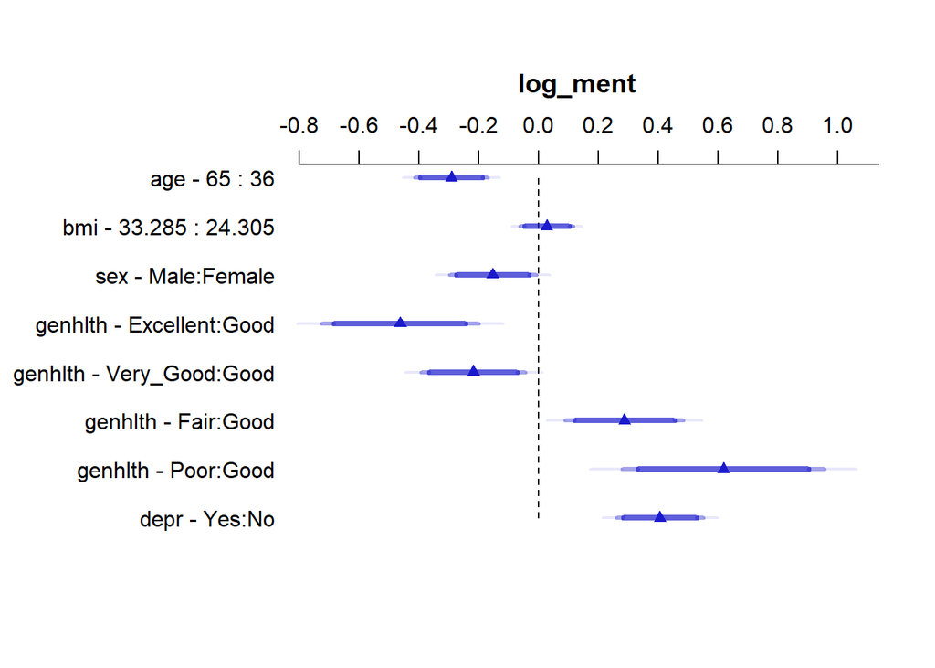

```r
plot(summary(modelA_ols, conf.int = 0.90))
```

From this plot we can see how `genhlth` and `depr` seem to have some of the greatest effects on outcome. `age` and `sex` have more modest effects, while `bmi` seems to be having the least effect.

### 8.8.3 Numerical Description of Effect Sizes

```r
summary(modelA_ols, conf.int = 0.90) |> kable(digits = 3)
```

|  | Low | High | Diff. | Effect | S.E. | Lower 0.9 | Upper 0.9 | Type |
| --- | --- | --- | --- | --- | --- | --- | --- | --- |
| age | 36.000 | 65.000 | 29.00 | -0.293 | 0.063 | -0.396 | -0.190 | 1 |
| bmi | 24.305 | 33.285 | 8.98 | 0.026 | 0.045 | -0.049 | 0.101 | 1 |
| sex - Male:Female | 1.000 | 2.000 | NA | -0.154 | 0.074 | -0.276 | -0.032 | 1 |
| genhlth - Excellent:Good | 3.000 | 1.000 | NA | -0.464 | 0.134 | -0.684 | -0.244 | 1 |
| genhlth - Very_Good:Good | 3.000 | 2.000 | NA | -0.219 | 0.089 | -0.365 | -0.072 | 1 |
| genhlth - Fair:Good | 3.000 | 4.000 | NA | 0.286 | 0.101 | 0.120 | 0.452 | 1 |
| genhlth - Poor:Good | 3.000 | 5.000 | NA | 0.616 | 0.173 | 0.332 | 0.901 | 1 |
| depr - Yes:No | 1.000 | 2.000 | NA | 0.405 | 0.074 | 0.282 | 0.527 | 1 |

### 8.8.4 Nomogram of Winning Model

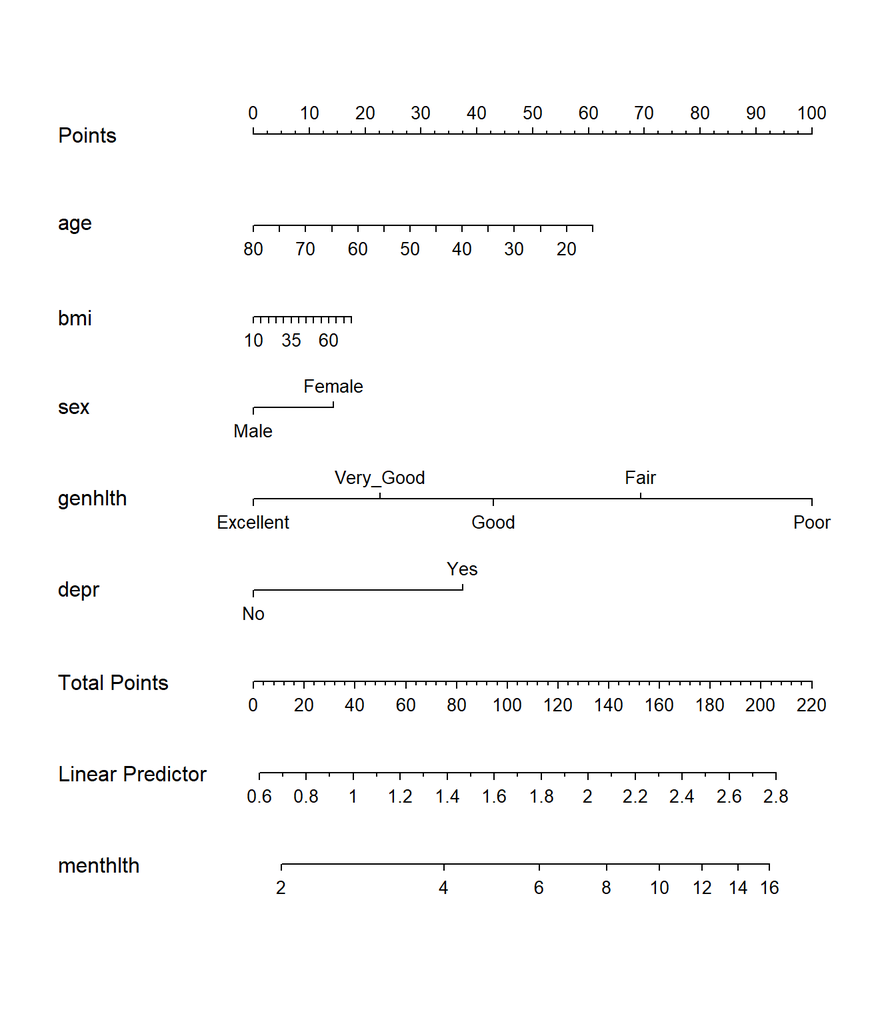

```r
plot(nomogram(modelA_ols, fun = exp, funlabel = "menthlth"))
```

By back transforming our outcome on the nomogram, it is easier to see the effects of each variable on the outcome. We can now see properly that `age` is negatively related to `menhlth` while `bmi` is positively related to `menthlth`. A `sex` value of ‘Female’ and a `depr` value of ‘Yes’ also lead to higher predictions of `menthlth`. We can also see that the lower levels of `genhlth` are associated with higher `menthlth`. We can also see the logarithmic nature of our outcome quite clearly.

I was surprised to see that `age` had a decently large effect on the outcome, I would have expected it to be similar to `bmi`. Two variables I thought would have a large effect, `depr` and `genhlth` do display large effects on `menthlth`.

### 8.8.5 Prediction for a New Subject

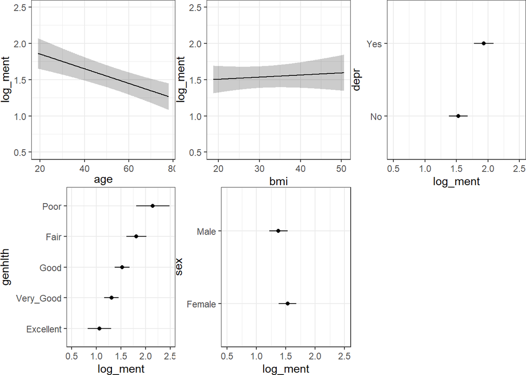

```r
ggplot(Predict(modelA_ols))
```

```r
new_subject <-
  data.frame(age = c(25), bmi = c(40), sex = c('Female'),
             genhlth = c('Very_Good'), depr = c('Yes'))

preds1 <- predict.lm(modelA_lm, newdata = new_subject,
                     interval = "prediction", level = 0.90)

exp(preds1)
```

```
       fit      lwr      upr
1 7.556179 1.649193 34.62049
```

| age | bmi | sex | genhlth | depr | estimate (90% CI) |
| --- | --- | --- | --- | --- | --- |
| 25 | 40 | Female | Very Good | Yes | 7.56 (1.65, 34.62) |

Our prediction interval here is not great, as it almost spans our entire range of values for `menthlth`, which was 1-29.

# 9 Logistic Regression Analyses

## 9.1 Missingness

I will be assuming my predictor variables are missing at random and so I will be using single imputation for my analysis. I am also assuming my outcome, `flushot`, is missing completely at random, so we filtered to complete cases earlier.

```r
miss_var_summary(logistic_model_predictors) |> filter(n_miss > 0)
```

```
# A tibble: 3 × 3
  variable n_miss pct_miss
  <chr>     <int>    <num>
1 insur        87     4.35
2 afford        5     0.25
3 educ          3     0.15
```

Before imputation I am missing data on 3 variables: `insur`, `afford`, and `educ`.

```r
brfss_log_imp <-
  mice(brfss_2024, m = 1, seed = 432, print = FALSE) |>
  complete() |>
  tibble()
```

```r
n_miss(brfss_log_imp)
```

```
[1] 0
```

After imputation we no longer have any missing values.

## 9.2 Model Y

We’ll predict Pr(`flushot` = 1), the probability of having a flu shot in the last 12 months, as a function of `age`, `insur`, `educ`, `rural` and `afford`.

### 9.2.1 Fitting Model Y

```r
modelY_glm <- glm(flushot ~ age + insur + educ + rural + afford,
            data = brfss_log_imp, family = binomial())

ddd <- datadist(brfss_log_imp)
options(datadist = "ddd")

modelY_lrm <- lrm(flushot ~ age + insur + educ + rural + afford,
            data = brfss_log_imp, x = TRUE, y = TRUE)
```

We fit with both lrm and glm so we can use them for different functions later on.

### 9.2.2 Tidied Odds Ratio Estimates (Model Y)

```r
model_parameters(modelY_glm, ci = 0.90, exponentiate = TRUE) |>
  print_md(digits = 3)
```

| Parameter | Odds Ratio | SE | 90% CI | z | p |
| --- | --- | --- | --- | --- | --- |
| (Intercept) | 0.072 | 0.020 | (0.045, 0.113) | -9.415 | < .001 |
| age | 1.033 | 0.004 | (1.026, 1.039) | 8.234 | < .001 |
| insur (Medicare) | 1.076 | 0.141 | (0.867, 1.335) | 0.559 | 0.576 |
| insur (Medicaid) | 1.037 | 0.193 | (0.761, 1.405) | 0.193 | 0.847 |
| insur (Other) | 0.799 | 0.134 | (0.606, 1.051) | -1.337 | 0.181 |
| educ (Some_College) | 1.241 | 0.153 | (1.013, 1.520) | 1.754 | 0.079 |
| educ (College_Grad) | 2.526 | 0.294 | (2.087, 3.062) | 7.951 | < .001 |
| rural (Urban) | 1.311 | 0.237 | (0.976, 1.769) | 1.497 | 0.134 |
| afford (Yes) | 0.674 | 0.130 | (0.489, 0.921) | -2.050 | 0.040 |

We exponentiate the coefficients so that we can look at the odds ratios.

### 9.2.3 Effects Plot (Model Y)

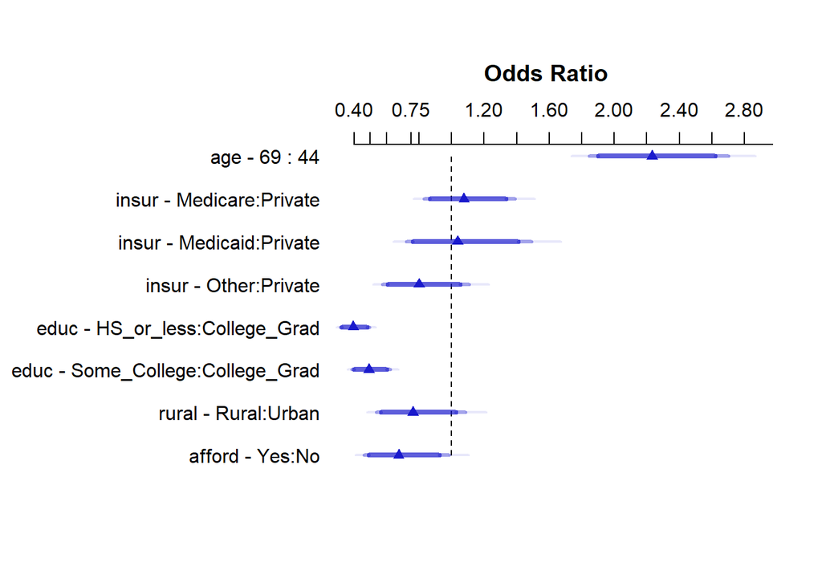

```r
plot(summary(modelY_lrm, conf.int = 0.90))
```

From this, it looks like `age` and `educ` are having some of the strongest effects on our outcome `flushot`.

```r
kable(summary(modelY_lrm, conf.int = 0.90), digits = 3)
```

|  | Low | High | Diff. | Effect | S.E. | Lower 0.9 | Upper 0.9 | Type |
| --- | --- | --- | --- | --- | --- | --- | --- | --- |
| age | 44 | 69 | 25 | 0.803 | 0.097 | 0.642 | 0.963 | 1 |
| Odds Ratio | 44 | 69 | 25 | 2.232 | NA | 1.901 | 2.620 | 2 |
| insur - Medicare:Private | 1 | 2 | NA | 0.073 | 0.131 | -0.143 | 0.289 | 1 |
| Odds Ratio | 1 | 2 | NA | 1.076 | NA | 0.867 | 1.335 | 2 |
| insur - Medicaid:Private | 1 | 3 | NA | 0.036 | 0.186 | -0.270 | 0.342 | 1 |
| Odds Ratio | 1 | 3 | NA | 1.037 | NA | 0.763 | 1.408 | 2 |
| insur - Other:Private | 1 | 4 | NA | -0.224 | 0.167 | -0.499 | 0.051 | 1 |
| Odds Ratio | 1 | 4 | NA | 0.799 | NA | 0.607 | 1.053 | 2 |
| educ - HS_or_less:College_Grad | 3 | 1 | NA | -0.926 | 0.117 | -1.118 | -0.735 | 1 |
| Odds Ratio | 3 | 1 | NA | 0.396 | NA | 0.327 | 0.480 | 2 |
| educ - Some_College:College_Grad | 3 | 2 | NA | -0.710 | 0.121 | -0.909 | -0.511 | 1 |
| Odds Ratio | 3 | 2 | NA | 0.491 | NA | 0.403 | 0.600 | 2 |
| rural - Rural:Urban | 2 | 1 | NA | -0.270 | 0.181 | -0.568 | 0.027 | 1 |
| Odds Ratio | 2 | 1 | NA | 0.763 | NA | 0.567 | 1.027 | 2 |
| afford - Yes:No | 1 | 2 | NA | -0.394 | 0.192 | -0.710 | -0.078 | 1 |
| Odds Ratio | 1 | 2 | NA | 0.674 | NA | 0.492 | 0.925 | 2 |

Looking at the variable `age`, if we have two subjects with the same values of `insur`, `educ`, `rural` and `afford`, but subject A has an `age` of 44 and subject B has an `age` of 69, our model Y predicts that the odds of subject B having our outcome `flushot` will be 2.232 times the odds of subject A having the outcome `flushot`. In addition, our data are consistent at the 90% confidence level with that odds ratio comparing A to B falling between 1.901 and 2.620, assuming both that our data are a random sample of the population of interest, and that our model Y is correct.

### 9.2.4 Summarizing Fit (Model Y)

```r
modelY_lrm
```

```
Logistic Regression Model

lrm(formula = flushot ~ age + insur + educ + rural + afford,
    data = brfss_log_imp, x = TRUE, y = TRUE)

                       Model Likelihood       Discrimination    Rank Discrim.
                             Ratio Test              Indexes          Indexes
Obs          2000    LR chi2     215.96       R2       0.137    C       0.692
 0           1098    d.f.             8      R2(8,2000)0.099    Dxy     0.384
 1            902    Pr(> chi2) <0.0001    R2(8,1485.6)0.131    gamma   0.385
max |deriv| 3e-08                             Brier    0.221    tau-a   0.190

                  Coef    S.E.   Wald Z Pr(>|Z|)
Intercept         -2.6370 0.2801 -9.41  <0.0001
age                0.0321 0.0039  8.23  <0.0001
insur=Medicare     0.0734 0.1313  0.56  0.5762
insur=Medicaid     0.0360 0.1860  0.19  0.8467
insur=Other       -0.2238 0.1673 -1.34  0.1811
educ=Some_College  0.2161 0.1232  1.75  0.0795
educ=College_Grad  0.9265 0.1165  7.95  <0.0001
rural=Urban        0.2705 0.1807  1.50  0.1344
afford=Yes        -0.3939 0.1922 -2.05  0.0404
```

Our Nagelkerke R<sup>2</sup> estimate for model Y is 0.137 and our C statistic estimate is 0.692. Neither of these are that exciting, but our model is guessing better than random chance as our C statistic is greater than 0.5.

```r
glance(modelY_glm) |>
  mutate(df = nobs - df.residual - 1) |>
  select(AIC, BIC, df, df.residual, nobs) |>
  kable(digits = 1)
```

| AIC | BIC | df | df.residual | nobs |
| --- | --- | --- | --- | --- |
| 2555.4 | 2605.8 | 8 | 1991 | 2000 |

The AIC and BIC are not helpful right now, but they will allow us to compare models later. This also allows us to easily see that we have 8 degrees of freedom in model Y.

### 9.2.5 Confusion Matrix (Model Y)

```r
modelY_aug <- augment(modelY_glm, type.predict = "response")

cp1 <- cutpointr(data = modelY_aug, .fitted, flushot,
                 pos_class = 1, neg_class = 0,
                 method = maximize_metric, metric = sum_sens_spec)
```

```
Assuming the positive class has higher x values
```

```r
cp1 |> select(direction, optimal_cutpoint, method, sum_sens_spec) |> kable(digits = 3)
```

| direction | optimal_cutpoint | method | sum_sens_spec |
| --- | --- | --- | --- |
| >= | 0.406 | maximize_metric | 1.299 |

Using cutpointr, the decision rule that maximizes sensitivity and specificity is approximately 0.406. We will be using this cut point for both model Y and model Z, so we will round this down to 0.4. This means my prediction rule for this confusion matrix is that the fitted value of Pr(`flushot` = 1) needs to be greater than or equal to 0.4 for me to predict `flushot` is 1, and otherwise I predict 0.

```r
cm1 <- confusionMatrix(data = factor(modelY_aug$.fitted >= 0.4),
                       reference = factor(modelY_aug$flushot == 1),
                       positive = "TRUE")
cm1
```

```
Confusion Matrix and Statistics

          Reference
Prediction FALSE TRUE
     FALSE   557  196
     TRUE    541  706

               Accuracy : 0.6315
                 95% CI : (0.6099, 0.6527)
    No Information Rate : 0.549
    P-Value [Acc > NIR] : 4.687e-14

                  Kappa : 0.2804

 Mcnemar's Test P-Value : < 2.2e-16

            Sensitivity : 0.7827
            Specificity : 0.5073
         Pos Pred Value : 0.5662
         Neg Pred Value : 0.7397
             Prevalence : 0.4510
         Detection Rate : 0.3530
   Detection Prevalence : 0.6235
      Balanced Accuracy : 0.6450

       'Positive' Class : TRUE
```

| Model | Classification Rule | Sensitivity | Specificity | Pos. Pred. Value |
| --- | --- | --- | --- | --- |
| Y | Predicted Pr(`flushot` = 1) >= 0.4 | 0.7827 | 0.5073 | 0.5662 |

## 9.3 Non-Linearity

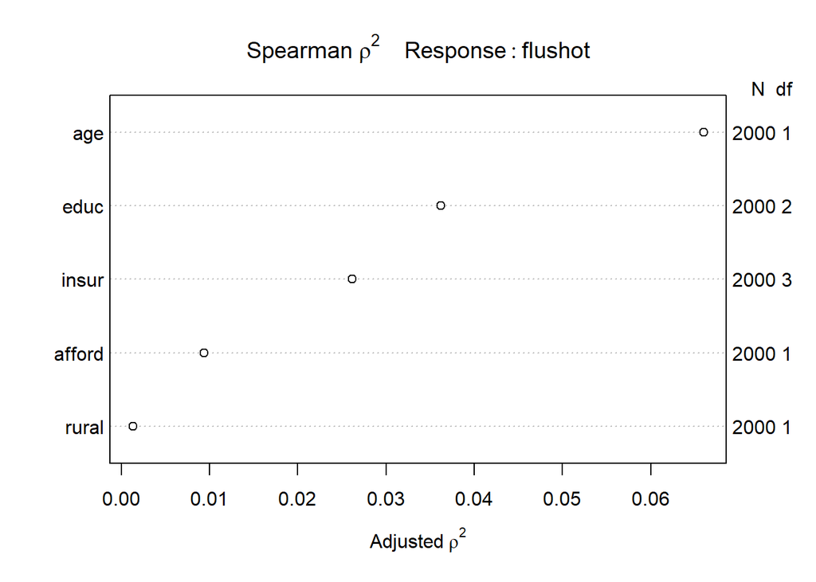

```r
plot(spearman2(flushot ~ age + insur + educ + rural + afford,
            data = brfss_log_imp))
```

The Spearman $\rho^2$ plot suggests the use of non-linear terms with `age` and `educ`. As such, I will add a 5-knot restricted cubic spline to age, which has 4 degrees of freedom, and an interaction between `age` and `educ` which will add 2 more degrees of freedom.

## 9.4 Model Z

Model Z will contain two non-linear terms, adding up to an additional 5 degrees of freedom, to model Y.

### 9.4.1 Fitting Model Z

```r
modelZ_glm <- glm(flushot ~ rcs(age, 5) + insur + educ + rural + afford + age %ia% educ,
                  data = brfss_log_imp, family = binomial())

ddd <- datadist(brfss_log_imp)
options(datadist = "ddd")

modelZ_lrm <- lrm(flushot ~ rcs(age, 5) + insur + educ + rural + afford + age %ia% educ,
                 data = brfss_log_imp, x = TRUE, y = TRUE)
```

### 9.4.2 Tidied Odds Ratio Estimates (Model Z)

```r
tidy(modelZ_glm, exponentiate = TRUE, conf.int = TRUE, conf.level = 0.90) |>
  select(term, estimate, se = std.error,
         low90 = conf.low, high90 = conf.high, p = p.value) |>
  kable(digits = 3)
```

| term | estimate | se | low90 | high90 | p |
| --- | --- | --- | --- | --- | --- |
| (Intercept) | 0.268 | 0.557 | 0.105 | 0.659 | 0.018 |
| rcs(age, 5)age | 0.984 | 0.016 | 0.959 | 1.010 | 0.297 |
| rcs(age, 5)age’ | 1.118 | 0.046 | 1.036 | 1.206 | 0.016 |
| rcs(age, 5)age’’ | 0.770 | 0.286 | 0.481 | 1.232 | 0.361 |
| rcs(age, 5)age’’’ | 0.858 | 0.779 | 0.238 | 3.089 | 0.844 |
| insurMedicare | 0.839 | 0.151 | 0.654 | 1.074 | 0.244 |
| insurMedicaid | 1.067 | 0.191 | 0.778 | 1.458 | 0.734 |
| insurOther | 0.728 | 0.173 | 0.546 | 0.965 | 0.066 |
| educSome_College | 2.263 | 0.494 | 1.002 | 5.105 | 0.098 |
| educCollege_Grad | 8.336 | 0.448 | 4.018 | 17.580 | 0.000 |
| ruralUrban | 1.289 | 0.184 | 0.955 | 1.748 | 0.167 |
| affordYes | 0.690 | 0.194 | 0.499 | 0.945 | 0.055 |
| age %ia% educage * educ=Some_College | 0.990 | 0.008 | 0.977 | 1.004 | 0.234 |
| age %ia% educage * educ=College_Grad | 0.980 | 0.007 | 0.968 | 0.992 | 0.007 |

Once again, we exponentiate the coefficients so that we can look at the odds ratios.

### 9.4.3 Effects Plot (Model Z)

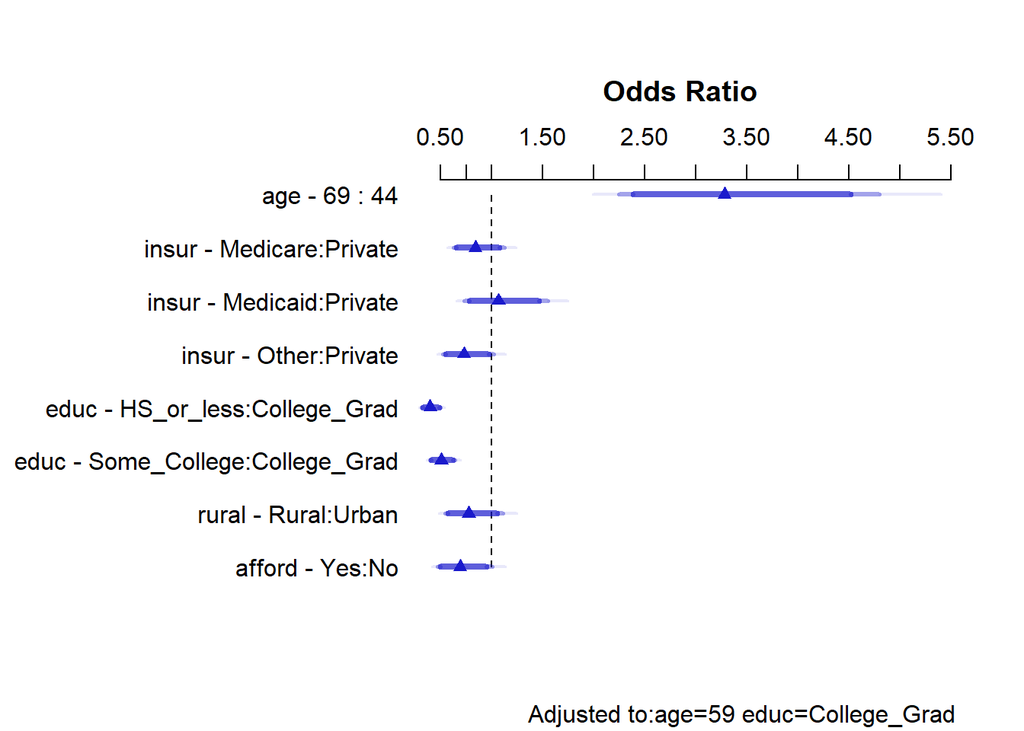

```r
plot(summary(modelZ_lrm, conf.int = 0.90))
```

It looks like `age` is having a much greater effect on `flushot` then the rest of the variables now.

```r
summary(modelZ_lrm, conf.int = 0.90) |> kable(digits = 3)
```

|  | Low | High | Diff. | Effect | S.E. | Lower 0.9 | Upper 0.9 | Type |
| --- | --- | --- | --- | --- | --- | --- | --- | --- |
| age | 44 | 69 | 25 | 1.189 | 0.194 | 0.870 | 1.508 | 1 |
| Odds Ratio | 44 | 69 | 25 | 3.282 | NA | 2.386 | 4.516 | 2 |
| insur - Medicare:Private | 1 | 2 | NA | -0.176 | 0.151 | -0.423 | 0.072 | 1 |
| Odds Ratio | 1 | 2 | NA | 0.839 | NA | 0.655 | 1.075 | 2 |
| insur - Medicaid:Private | 1 | 3 | NA | 0.065 | 0.191 | -0.249 | 0.379 | 1 |
| Odds Ratio | 1 | 3 | NA | 1.067 | NA | 0.780 | 1.460 | 2 |
| insur - Other:Private | 1 | 4 | NA | -0.318 | 0.173 | -0.602 | -0.034 | 1 |
| Odds Ratio | 1 | 4 | NA | 0.728 | NA | 0.548 | 0.967 | 2 |
| educ - HS_or_less:College_Grad | 3 | 1 | NA | -0.926 | 0.120 | -1.124 | -0.728 | 1 |
| Odds Ratio | 3 | 1 | NA | 0.396 | NA | 0.325 | 0.483 | 2 |
| educ - Some_College:College_Grad | 3 | 2 | NA | -0.683 | 0.123 | -0.886 | -0.480 | 1 |
| Odds Ratio | 3 | 2 | NA | 0.505 | NA | 0.412 | 0.619 | 2 |
| rural - Rural:Urban | 2 | 1 | NA | -0.254 | 0.184 | -0.556 | 0.048 | 1 |
| Odds Ratio | 2 | 1 | NA | 0.776 | NA | 0.574 | 1.049 | 2 |
| afford - Yes:No | 1 | 2 | NA | -0.372 | 0.194 | -0.691 | -0.052 | 1 |
| Odds Ratio | 1 | 2 | NA | 0.690 | NA | 0.501 | 0.949 | 2 |

### 9.4.4 Summarizing Fit (Model Z)

```r
modelZ_lrm
```

```
Logistic Regression Model

lrm(formula = flushot ~ rcs(age, 5) + insur + educ + rural +
    afford + age %ia% educ, data = brfss_log_imp, x = TRUE, y = TRUE)

                       Model Likelihood        Discrimination    Rank Discrim.
                             Ratio Test               Indexes          Indexes
Obs          2000    LR chi2     247.96        R2       0.156    C       0.696
 0           1098    d.f.            13      R2(13,2000)0.111    Dxy     0.393
 1            902    Pr(> chi2) <0.0001    R2(13,1485.6)0.146    gamma   0.394
max |deriv| 3e-06                              Brier    0.218    tau-a   0.195

                        Coef    S.E.   Wald Z Pr(>|Z|)
Intercept               -1.3182 0.5572 -2.37  0.0180
age                     -0.0163 0.0156 -1.04  0.2966
age'                     0.1111 0.0461  2.41  0.0159
age''                   -0.2614 0.2862 -0.91  0.3611
age'''                  -0.1534 0.7791 -0.20  0.8439
insur=Medicare          -0.1755 0.1506 -1.17  0.2437
insur=Medicaid           0.0647 0.1908  0.34  0.7343
insur=Other             -0.3179 0.1727 -1.84  0.0656
educ=Some_College        0.8167 0.4943  1.65  0.0985
educ=College_Grad        2.1206 0.4483  4.73  <0.0001
rural=Urban              0.2539 0.1836  1.38  0.1667
afford=Yes              -0.3717 0.1941 -1.92  0.0555
age * educ=Some_College -0.0097 0.0082 -1.19  0.2342
age * educ=College_Grad -0.0202 0.0075 -2.71  0.0068
```

```r
glance(modelZ_glm) |>
  mutate(df = nobs - df.residual - 1) |>
  select(AIC, BIC, df, df.residual, nobs) |>
  kable(digits = 1)
```

| AIC | BIC | df | df.residual | nobs |
| --- | --- | --- | --- | --- |
| 2533.4 | 2611.8 | 13 | 1986 | 2000 |

We will use the AIC and BIC later for selecting our final model. We can also easily see that we have 13 degrees of freedom, 5 more than model Y.

### 9.4.5 Confusion Matrix (Model Z)

As in model Y, my prediction rule for this confusion matrix is that the fitted value of Pr(`flushot` = 1) needs to be greater than or equal to 0.4 for me to predict `flushot` is 1, and otherwise I predict 0.

```r
modelZ_aug <- augment(modelZ_glm, type.predict = "response")

cm2 <- confusionMatrix(data = factor(modelZ_aug$.fitted >= 0.4),
                       reference = factor(modelZ_aug$flushot == 1),
                       positive = "TRUE")
cm2
```

```
Confusion Matrix and Statistics

          Reference
Prediction FALSE TRUE
     FALSE   527  178
     TRUE    571  724

               Accuracy : 0.6255
                 95% CI : (0.6039, 0.6468)
    No Information Rate : 0.549
    P-Value [Acc > NIR] : 2.585e-12

                  Kappa : 0.272

 Mcnemar's Test P-Value : < 2.2e-16

            Sensitivity : 0.8027
            Specificity : 0.4800
         Pos Pred Value : 0.5591
         Neg Pred Value : 0.7475
             Prevalence : 0.4510
         Detection Rate : 0.3620
   Detection Prevalence : 0.6475
      Balanced Accuracy : 0.6413

       'Positive' Class : TRUE
```

| Model | Classification Rule | Sensitivity | Specificity | Pos. Pred. Value |
| --- | --- | --- | --- | --- |
| Z | Predicted Pr(`flushot` = 1) >= 0.4 | 0.8027 | 0.4800 | 0.5591 |

## 9.5 Validating Models Y and Z

```r
set.seed(4323); (valY <- validate(modelY_lrm, method = "boot", B = 300))
```

```
          index.orig training    test optimism index.corrected   Lower  Upper
Dxy           0.3836   0.3878  0.3767   0.0110          0.3725  0.3227 0.4178
R2            0.1369   0.1416  0.1326   0.0089          0.1280  0.0915 0.1602
Intercept     0.0000   0.0000 -0.0044   0.0044         -0.0044 -0.1285 0.1112
Slope         1.0000   1.0000  0.9666   0.0334          0.9666  0.7892 1.1603
Emax          0.0000   0.0000  0.0227  -0.0227          0.0227 -0.0037 0.0556
D             0.1075   0.1115  0.1039   0.0075          0.0999  0.0691 0.1267
U            -0.0010  -0.0010  0.0003  -0.0013          0.0003 -0.0018 0.0046
Q             0.1085   0.1125  0.1037   0.0088          0.0997  0.0649 0.1266
B             0.2214   0.2205  0.2225  -0.0020          0.2234  0.2173 0.2314
g             0.8112   0.8280  0.7959   0.0322          0.7790  0.6459 0.8974
gp            0.1825   0.1852  0.1795   0.0057          0.1768  0.1529 0.1993
            n
Dxy       300
R2        300
Intercept 300
Slope     300
Emax      300
D         300
U         300
Q         300
B         300
g         300
gp        300
```

```r
set.seed(4324); (valZ <- validate(modelZ_lrm, method = "boot", B = 300))
```

```
          index.orig training    test optimism index.corrected   Lower  Upper
Dxy           0.3930   0.4023  0.3864   0.0159          0.3771  0.3345 0.4229
R2            0.1560   0.1634  0.1490   0.0145          0.1415  0.1090 0.1767
Intercept     0.0000   0.0000 -0.0068   0.0068         -0.0068 -0.1260 0.1078
Slope         1.0000   1.0000  0.9461   0.0539          0.9461  0.8075 1.1210
Emax          0.0000   0.0000  0.0232  -0.0232          0.0232 -0.0023 0.0563
D             0.1235   0.1299  0.1176   0.0123          0.1112  0.0832 0.1407
U            -0.0010  -0.0010  0.0004  -0.0014          0.0004 -0.0017 0.0048
Q             0.1245   0.1309  0.1172   0.0137          0.1108  0.0792 0.1409
B             0.2184   0.2169  0.2199  -0.0030          0.2214  0.2146 0.2287
g             0.8774   0.9033  0.8524   0.0510          0.8264  0.7108 0.9509
gp            0.1959   0.1996  0.1907   0.0089          0.1869  0.1667 0.2098
            n
Dxy       300
R2        300
Intercept 300
Slope     300
Emax      300
D         300
U         300
Q         300
B         300
g         300
gp        300
```

### 9.5.1 Validated $R^2$ and $C$ statistics for each model

| Model | Validated $R^2$ | Validated C | AIC | BIC | df |
| --- | --- | --- | --- | --- | --- |
| Y | 0.128 | 0.6863 | 2555.4 | 2605.8 | 8 |
| Z | 0.1415 | 0.6885 | 2533.4 | 2611.8 | 13 |

## 9.6 Final Logistic Regression Model

I prefer model Z because it has a higher validated R<sup>2</sup> and validated C statistic, as well as a lower AIC and higher sensitivity. The models perform very similarly, with no model completely dominating the other in all our measures, but there is a bit more of a difference between models for R<sup>2</sup> and sensitivity, that makes model Z a compelling choice. I would probably be happy to use either, as I am not sure that the small difference is worth using the more complicated model, but I will still go with model Z.

### 9.6.1 Winning Model’s Parameter Estimates

```r
tidy(modelZ_glm, exponentiate = TRUE, conf.int = TRUE, conf.level = 0.90) |>
  select(term, estimate, se = std.error,
         low90 = conf.low, high90 = conf.high, p = p.value) |>
  kable(digits = 3)
```

| term | estimate | se | low90 | high90 | p |
| --- | --- | --- | --- | --- | --- |
| (Intercept) | 0.268 | 0.557 | 0.105 | 0.659 | 0.018 |
| rcs(age, 5)age | 0.984 | 0.016 | 0.959 | 1.010 | 0.297 |
| rcs(age, 5)age’ | 1.118 | 0.046 | 1.036 | 1.206 | 0.016 |
| rcs(age, 5)age’’ | 0.770 | 0.286 | 0.481 | 1.232 | 0.361 |
| rcs(age, 5)age’’’ | 0.858 | 0.779 | 0.238 | 3.089 | 0.844 |
| insurMedicare | 0.839 | 0.151 | 0.654 | 1.074 | 0.244 |
| insurMedicaid | 1.067 | 0.191 | 0.778 | 1.458 | 0.734 |
| insurOther | 0.728 | 0.173 | 0.546 | 0.965 | 0.066 |
| educSome_College | 2.263 | 0.494 | 1.002 | 5.105 | 0.098 |
| educCollege_Grad | 8.336 | 0.448 | 4.018 | 17.580 | 0.000 |
| ruralUrban | 1.289 | 0.184 | 0.955 | 1.748 | 0.167 |
| affordYes | 0.690 | 0.194 | 0.499 | 0.945 | 0.055 |
| age %ia% educage * educ=Some_College | 0.990 | 0.008 | 0.977 | 1.004 | 0.234 |
| age %ia% educage * educ=College_Grad | 0.980 | 0.007 | 0.968 | 0.992 | 0.007 |

It looks like the `educ` levels have some of the bigger odds ratios.

### 9.6.2 Plot of Effect Sizes for Winning Model

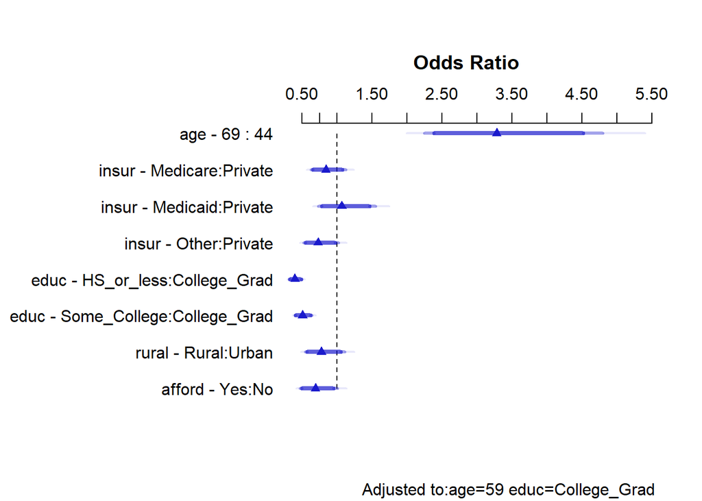

```r
plot(summary(modelZ_lrm, conf.int = 0.90))
```

Here it is easier to see the effect of `age` since it isn’t divided into degrees like with our coefficients. `age` is definitely having the largest effect on our model.

### 9.6.3 Numerical Description of Effect Sizes

```r
summary(modelZ_lrm, conf.int = 0.90) |> kable(digits = 3)
```

|  | Low | High | Diff. | Effect | S.E. | Lower 0.9 | Upper 0.9 | Type |
| --- | --- | --- | --- | --- | --- | --- | --- | --- |
| age | 44 | 69 | 25 | 1.189 | 0.194 | 0.870 | 1.508 | 1 |
| Odds Ratio | 44 | 69 | 25 | 3.282 | NA | 2.386 | 4.516 | 2 |
| insur - Medicare:Private | 1 | 2 | NA | -0.176 | 0.151 | -0.423 | 0.072 | 1 |
| Odds Ratio | 1 | 2 | NA | 0.839 | NA | 0.655 | 1.075 | 2 |
| insur - Medicaid:Private | 1 | 3 | NA | 0.065 | 0.191 | -0.249 | 0.379 | 1 |
| Odds Ratio | 1 | 3 | NA | 1.067 | NA | 0.780 | 1.460 | 2 |
| insur - Other:Private | 1 | 4 | NA | -0.318 | 0.173 | -0.602 | -0.034 | 1 |
| Odds Ratio | 1 | 4 | NA | 0.728 | NA | 0.548 | 0.967 | 2 |
| educ - HS_or_less:College_Grad | 3 | 1 | NA | -0.926 | 0.120 | -1.124 | -0.728 | 1 |
| Odds Ratio | 3 | 1 | NA | 0.396 | NA | 0.325 | 0.483 | 2 |
| educ - Some_College:College_Grad | 3 | 2 | NA | -0.683 | 0.123 | -0.886 | -0.480 | 1 |
| Odds Ratio | 3 | 2 | NA | 0.505 | NA | 0.412 | 0.619 | 2 |
| rural - Rural:Urban | 2 | 1 | NA | -0.254 | 0.184 | -0.556 | 0.048 | 1 |
| Odds Ratio | 2 | 1 | NA | 0.776 | NA | 0.574 | 1.049 | 2 |
| afford - Yes:No | 1 | 2 | NA | -0.372 | 0.194 | -0.691 | -0.052 | 1 |
| Odds Ratio | 1 | 2 | NA | 0.690 | NA | 0.501 | 0.949 | 2 |

Looking at the variable `educ`, if we have two subjects with the same values of `insur`, `age`, `rural` and `afford`, but subject A has an `educ` of ‘Some College’ and subject B has an `educ` of ‘College Grad’, our model Z predicts that the odds of subject A having our outcome `flushot` will be 0.505 times the odds of subject B having the outcome `flushot`. In addition, our data are consistent at the 90% confidence level with that odds ratio comparing A to B falling between 0.412 and 0.619, assuming both that our data are a random sample of the population of interest, and that our model Z is correct.

### 9.6.4 Plot of ROC Curve for Winning Model

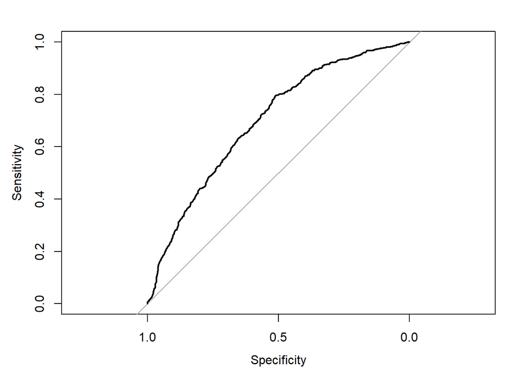

```r
roc.modelZ <-
    roc(brfss_log_imp$flushot ~ predict(modelZ_glm, type="response"),
        ci = TRUE)
plot(roc.modelZ)
```

Here we can see that our model performs better than random chance, however a C statistic of 0.696 is not very exciting. This also displays the C statistic in our training data, but the validated C statistic is 0.6885.

### 9.6.5 Validated $R^2$ and $C$ statistic for Winning Model

- The validated R<sup>2</sup> statistic for Model Z is 0.1415, and
- The validated C statistic for Model Z is 0.6885.

### 9.6.6 Nomogram of Winning Model

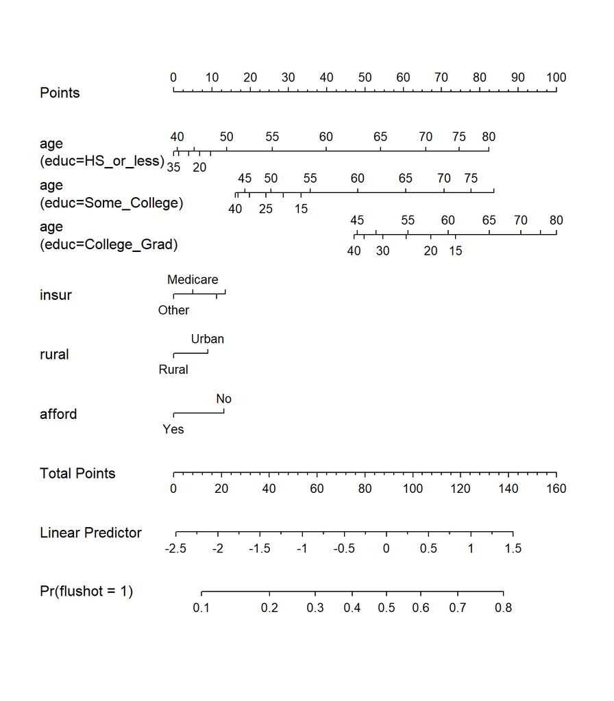

```r
plot(nomogram(modelZ_lrm, fun = plogis, funlabel = "Pr(flushot = 1)"))
```

The nomogram shows us just how much more of an impact the variables of `age` and `educ` have than `insur`, `rural` and `afford`. We also get to see what the interaction between `age` and `educ` looks like, as model Z will predict a higher Pr(flushot=1) for subjects with higher education levels, even if they’re younger, but lower education levels have a much wider range depending on age.

I was surprised that `educ` ended up having a larger effect size than most of the other variables, as I expected `insur` or `rural` to have more of an impact on our outcome. I also found it interesting seeing what the non-linearity in our `age` variable looks like, as it decreased on the graph until around 40 for all education levels, before it begins to increase again.

### 9.6.7 Predictions for Two New Subjects

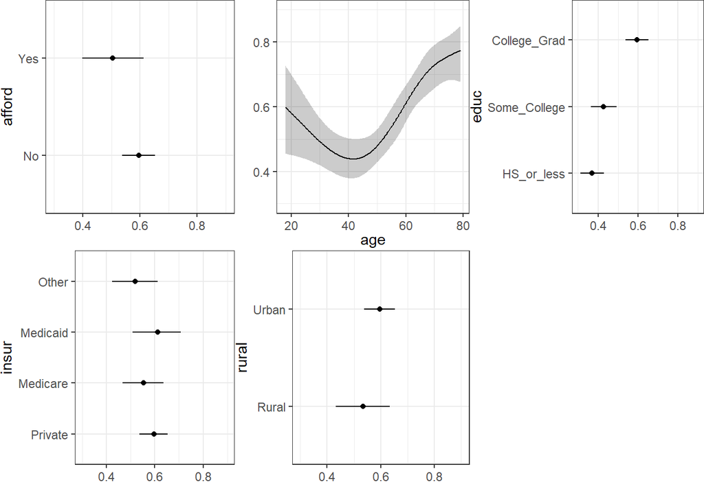

```r
ggplot(Predict(modelZ_lrm, fun = plogis))
```

In our prediction plot we can see that the `age` variable took advantage of the non-linearity we added with a large dip around 40 years old. We can also see that the different levels of `educ` seem to have greater differences between levels than our other categorical variables.

```r
new_subjects <-
  data.frame(age = c(25,60),
             insur = c('Private', 'Private'),
             rural = c('Urban', 'Urban'),
             afford = c('Yes', 'Yes'),
             educ = c('College_Grad', 'HS_or_less')) |>
  mutate(across(where(is.character), as_factor))

preds2 <- predict(modelZ_lrm, newdata = new_subjects,
                  type = "fitted")

preds2
```

```
        1         2
0.4429990 0.3050645
```

| Subject | age | insur | rural | afford | educ | Pr(flushot = 1) |
| --- | --- | --- | --- | --- | --- | --- |
| 1 | 25 | Private | Urban | Yes | College Grad | 0.443 |
| 2 | 60 | Private | Urban | Yes | HS or less | 0.305 |

According to our decided prediction rule of Pr(`flushot` = 1) >= 0.4 for me to predict `flushot` is 1, subject 1 is predicted to have a flu shot while subject 2 is predicted to not have a flu shot.

# 10 Discussion

## 10.1 Answering My Research Questions

My first research question for my linear regression was:

> How well can you predict the number of poor mental health days someone has had using demographic factors such as sex and age, and health factors like self-reported overall health, BMI, and previous depression diagnosis, in a sample of 679 subjects from the BRFSS 2024?

I would say that we cannot predict the number of poor mental health days all that well. Our validated R<sup>2</sup> value for our final model A, was only 0.1345 meaning the variables we picked did not account for much of the variation in our data. In addition, when we predicted the outcome for a new subject, the 90% prediction interval covered nearly the entire range of values of our outcome. Together, this tells me that the variables I picked were not as associated with my outcome as much as I thought they would be. For further exploration, perhaps a different data set with more variables about mental health could help me create a better model than the BRFSS data set, which is more general and has questions across a number of topics.

My second research question for my logistic regression was:

> What variables have the largest effect size when predicting whether or not a person has had a flu shot, from the variables of age, education level, living in a rural or urban county, insurance type, and whether the person can afford to see a doctor, in a sample of 2000 subjects from the 2024 BRFSS?

The variables that ended up with the largest effect size in our final model Z was first age, then education level. Age did not surprise me, as older people are usually encouraged to get flu shots more than younger people due to risk of more serious complications. Education level did surprise me however, as I thought there would be a difference between education levels, but I thought variables like type of insurance or living in an urban county would have greater effect sizes than education level. I would be interested to explore the relationship between my outcome and education levels further, mainly because I had to collapse my levels more than I would have liked to meet the 30 observations in each category rule. With a larger data set I could have more observations in each category and could look more at the differences between people who graduated high school and those that only attended some high school, for example.

## 10.2 Thoughts on Project A

Project A was the difficulty I expected it to be from my experience with projects in 431, in that I felt like I had all the tools in my belt to create visuals and statistical summaries, but it still took decent thought to interpret them. I also had to be careful to pay attention to details and look over my work over and over again, which is not difficult, but is time consuming and can get tiring when you have been staring at code for hours. Along with that, I wish I had spaced out my time better at the start of the project, so I wasn’t looking at code for so long. I didn’t feel like I rushed things or didn’t give myself enough time, but I would have liked to space out my work more, so I didn’t get as tired during my work. I find staring at numbers for hours on end doesn’t help my interpretation as much as giving myself a day to think more about it, which usually leads to more confidence in my interpretations.

# 11 Affirmation

I am certain that it is completely appropriate for these data to be shared with anyone, without any conditions. There are no concerns about privacy or security.

# 12 References

1. The BRFSS 2024 data can be found at https://www.cdc.gov/brfss/annual_data/annual_2024.html

# 13 Use of AI

AI supported the development of this project through R Studio’s spell-check and its help with filling in the details of R functions.